# Predicting Customer Churn in Telecommunications: A Comparative Analysis of Machine Learning Models with Recursive Feature Elimination

Peerapan Nantang

# Abstract

This study develops predictive models to identify customers likely to churn using a dataset of 5,000 customers. Class imbalance is addressed via weighting and sampling techniques. Recursive feature elimination identifies 13 key predictors, with daytime usage variables being most influential. A weighted random forest model achieves 86.7% F1 score and 89.9% balanced accuracy. Recommendations include focusing on daytime usage patterns, improving customer service, and minimizing attention on less impactful variables. The analysis demonstrates effective churn prediction using machine learning, with the proposed model and retention strategies potentially guiding customer retention efforts.

# Introduction

Customer retention is crucial for telecom companies to maintain revenue streams and profitability. However, with increasing competition, retaining customers has become challenging. To develop effective customer retention strategies, it is critical to understand the key drivers of customer churn.

This report presents an analysis of customer data, with a focus on 18 characteristics:

- `churn`
- `accountlength`
- `internationalplan`
- `voicemailplan`
- `numbervmailmessages`
- `totaldayminutes`
- `totaldaycalls`
- `totaldaycharge`
- `totaleveminutes`
- `totalevecalls`
- `totalevecharge`
- `totalnightminutes`
- `totalnightcalls`
- `totalnightcharge`
- `totalintlminutes`
- `totalintlcalls`
- `totalintlcharge`
- `numbercustomerservicecalls`

The objective of this report is to provide company leadership with actionable steps grounded in analytical insights to reduce customer churn

## Loading Libraries for Data Analysis and Machine Learning

```r
library(readr)
library(caret)
library(caretEnsemble)
library(tidyverse)
library(MLmetrics)
library(forcats)
library(flextable)
library(dlookr)
library(moments)
```

## Loading and Previewing a Data Frame

```r
df <- read_csv("churn.csv")

glimpse(df)
```

```
## Rows: 5,000
## Columns: 18
## $ churn                      <chr> "No", "No", "No", "No", "No", "No", "No", "…
## $ accountlength              <dbl> 128, 107, 137, 84, 75, 118, 121, 147, 117, …
## $ internationalplan          <chr> "no", "no", "no", "yes", "yes", "yes", "no"…
## $ voicemailplan              <chr> "yes", "yes", "no", "no", "no", "no", "yes"…
## $ numbervmailmessages        <dbl> 25, 26, 0, 0, 0, 0, 24, 0, 0, 37, 0, 0, 0, …
## $ totaldayminutes            <dbl> 265.1, 161.6, 243.4, 299.4, 166.7, 223.4, 2…
## $ totaldaycalls              <dbl> 110, 123, 114, 71, 113, 98, 88, 79, 97, 84,…
## $ totaldaycharge             <dbl> 45.07, 27.47, 41.38, 50.90, 28.34, 37.98, 3…
## $ totaleveminutes            <dbl> 197.4, 195.5, 121.2, 61.9, 148.3, 220.6, 34…
## $ totalevecalls              <dbl> 99, 103, 110, 88, 122, 101, 108, 94, 80, 11…
## $ totalevecharge             <dbl> 16.78, 16.62, 10.30, 5.26, 12.61, 18.75, 29…
## $ totalnightminutes          <dbl> 244.7, 254.4, 162.6, 196.9, 186.9, 203.9, 2…
## $ totalnightcalls            <dbl> 91, 103, 104, 89, 121, 118, 118, 96, 90, 97…
## $ totalnightcharge           <dbl> 11.01, 11.45, 7.32, 8.86, 8.41, 9.18, 9.57,…
## $ totalintlminutes           <dbl> 10.0, 13.7, 12.2, 6.6, 10.1, 6.3, 7.5, 7.1,…
## $ totalintlcalls             <dbl> 3, 3, 5, 7, 3, 6, 7, 6, 4, 5, 6, 5, 2, 5, 6…
## $ totalintlcharge            <dbl> 2.70, 3.70, 3.29, 1.78, 2.73, 1.70, 2.03, 1…
## $ numbercustomerservicecalls <dbl> 1, 1, 0, 2, 3, 0, 3, 0, 1, 0, 4, 0, 1, 3, 4…
```

The `df` data frame contains information about 5,000 customers. It has 18 columns.The `churn`, `internationalplan`, and `voicemailplan` columns are of character data type. The remaining columns are of double data type, which is a numeric data type capable of storing decimal or floating-point numbers.

Here is a brief description of each column:

- `churn`: Whether or not a customer has churned (i.e., left the company)
- `accountlength`: The length of the customer’s account in days
- `internationalplan`: Whether or not the customer has an international plan
- `voicemailplan`: Whether or not the customer has a voicemail plan
- `numbervmailmessages`: The number of voicemail messages the customer has
- `totaldayminutes`: The total number of minutes the customer used during the day
- `totaldaycalls`: The total number of calls the customer made during the day
- `totaldaycharge`: The total charge for the customer’s day usage
- `totaleveminutes`: The total number of minutes the customer used during the evening
- `totalevecalls`: The total number of calls the customer made during the evening
- `totalevecharge`: The total charge for the customer’s evening usage
- `totalnightminutes`: The total number of minutes the customer used during the night
- `totalnightcalls`: The total number of calls the customer made during the night
- `totalnightcharge`: The total charge for the customer’s night usage
- `totalintlminutes`: The total number of international minutes the customer used
- `totalintlcalls`: The total number of international calls the customer made
- `totalintlcharge`: The total charge for the customer’s international usage
- `numbercustomerservicecalls`: The number of times the customer called customer service

## Removing Duplicate Rows

```r
remove_duplicates <- function(df) {
  # Find duplicated rows
  dup_rows <- duplicated(df) | duplicated(df, fromLast = TRUE)

  # If there are no duplicated rows, return the original data frame
  if (!any(dup_rows)) {
    cat("No duplicates found\n")
    return(df)
  }

  # Find the row indices of the duplicated rows
  dup_indices <- which(dup_rows)

  # Group the duplicated rows by their values
  groups <- split(dup_indices, apply(df[dup_rows, ], 1, paste, collapse = ""))

  # Print a message to inform the user that duplicate rows were found
  cat("Duplicate rows found at indices:\n")

  # For each group of duplicated rows
  for (group in groups) {
    # Sort the row indices in ascending order
    group <- sort(group)

    # Print the row indices of the duplicates
    cat(paste(group, collapse = ", "), "\n")

    # Keep the row with the lowest index and remove the rest
    df <- df[!duplicated(df), ]
  }

  return(df)
}
```

```r
df <- remove_duplicates(df)
```

```
## No duplicates found
```

Analysis of the data frame has determined that no duplicate entries are present, indicating that each row is distinct and duplicate removal is not required.

## General Diagnosis

```r
diagnose(df) %>%
  flextable()
```

| variables | types | missing_count | missing_percent | unique_count | unique_rate |
| --- | --- | --- | --- | --- | --- |
| churn | character | 0 | 0 | 2 | 0.0004 |
| accountlength | numeric | 0 | 0 | 218 | 0.0436 |
| internationalplan | character | 0 | 0 | 2 | 0.0004 |
| voicemailplan | character | 0 | 0 | 2 | 0.0004 |
| numbervmailmessages | numeric | 0 | 0 | 48 | 0.0096 |
| totaldayminutes | numeric | 0 | 0 | 1,961 | 0.3922 |
| totaldaycalls | numeric | 0 | 0 | 123 | 0.0246 |
| totaldaycharge | numeric | 0 | 0 | 1,961 | 0.3922 |
| totaleveminutes | numeric | 0 | 0 | 1,879 | 0.3758 |
| totalevecalls | numeric | 0 | 0 | 126 | 0.0252 |
| totalevecharge | numeric | 0 | 0 | 1,659 | 0.3318 |
| totalnightminutes | numeric | 0 | 0 | 1,853 | 0.3706 |
| totalnightcalls | numeric | 0 | 0 | 131 | 0.0262 |
| totalnightcharge | numeric | 0 | 0 | 1,028 | 0.2056 |
| totalintlminutes | numeric | 0 | 0 | 170 | 0.0340 |
| totalintlcalls | numeric | 0 | 0 | 21 | 0.0042 |
| totalintlcharge | numeric | 0 | 0 | 170 | 0.0340 |
| numbercustomerservicecalls | numeric | 0 | 0 | 10 | 0.0020 |

## Filtering and Selecting Variables with Low Unique Counts

```r
diagnose(df) %>%
  filter(unique_count <= 10) %>%
  select(variables)
```

```
## # A tibble: 4 × 1
##   variables
##   <chr>
## 1 churn
## 2 internationalplan
## 3 voicemailplan
## 4 numbercustomerservicecalls
```

The result indicates that there are four potentially categorical columns: `churn`, `internationalplan`, `voicemailplan`, and `numbercustomerservicecalls`.

The `churn`, `internationalplan`, and `voicemailplan` columns each have two unique values, while the `numbercustomerservicecalls` column has ten unique values.

## Finding Unique Values in Selected Columns

```r
lapply(df[ ,c("churn",
             "internationalplan",
             "voicemailplan",
             "numbercustomerservicecalls")],unique)
```

```
## $churn
## [1] "No"  "Yes"
##
## $internationalplan
## [1] "no"  "yes"
##
## $voicemailplan
## [1] "yes" "no"
##
## $numbercustomerservicecalls
##  [1] 1 0 2 3 4 5 7 9 6 8
```

From the result, it can be seen that:

- The `churn` column contains two unique values: “No” and “Yes”. This suggests that the column is a binary variable indicating whether a customer has churned or not.
- Similarly, the `internationalplan` and `voicemailplan` columns also contain two unique values: “no” and “yes”. These columns represent binary variables indicating whether a customer has subscribed to an international plan or a voicemail plan, respectively.
- The `numbercustomerservicecalls` column contains 10 unique values ranging from 0 to 9. This suggests that the column is a numerical variable representing the number of customer service calls made by each customer.

Based on these observations, it can be concluded that the `churn`, `internationalplan`, and `voicemailplan` columns are categorical variables and should be converted to factors.

## Converting Selected Columns of the Data Frame to Factors

```r
df <- df %>%
  mutate_at(vars(churn, internationalplan, voicemailplan), factor) %>%
  glimpse()
```

```
## Rows: 5,000
## Columns: 18
## $ churn                      <fct> No, No, No, No, No, No, No, No, No, No, Yes…
## $ accountlength              <dbl> 128, 107, 137, 84, 75, 118, 121, 147, 117, …
## $ internationalplan          <fct> no, no, no, yes, yes, yes, no, yes, no, yes…
## $ voicemailplan              <fct> yes, yes, no, no, no, no, yes, no, no, yes,…
## $ numbervmailmessages        <dbl> 25, 26, 0, 0, 0, 0, 24, 0, 0, 37, 0, 0, 0, …
## $ totaldayminutes            <dbl> 265.1, 161.6, 243.4, 299.4, 166.7, 223.4, 2…
## $ totaldaycalls              <dbl> 110, 123, 114, 71, 113, 98, 88, 79, 97, 84,…
## $ totaldaycharge             <dbl> 45.07, 27.47, 41.38, 50.90, 28.34, 37.98, 3…
## $ totaleveminutes            <dbl> 197.4, 195.5, 121.2, 61.9, 148.3, 220.6, 34…
## $ totalevecalls              <dbl> 99, 103, 110, 88, 122, 101, 108, 94, 80, 11…
## $ totalevecharge             <dbl> 16.78, 16.62, 10.30, 5.26, 12.61, 18.75, 29…
## $ totalnightminutes          <dbl> 244.7, 254.4, 162.6, 196.9, 186.9, 203.9, 2…
## $ totalnightcalls            <dbl> 91, 103, 104, 89, 121, 118, 118, 96, 90, 97…
## $ totalnightcharge           <dbl> 11.01, 11.45, 7.32, 8.86, 8.41, 9.18, 9.57,…
## $ totalintlminutes           <dbl> 10.0, 13.7, 12.2, 6.6, 10.1, 6.3, 7.5, 7.1,…
## $ totalintlcalls             <dbl> 3, 3, 5, 7, 3, 6, 7, 6, 4, 5, 6, 5, 2, 5, 6…
## $ totalintlcharge            <dbl> 2.70, 3.70, 3.29, 1.78, 2.73, 1.70, 2.03, 1…
## $ numbercustomerservicecalls <dbl> 1, 1, 0, 2, 3, 0, 3, 0, 1, 0, 4, 0, 1, 3, 4…
```

The `churn`, `internationalplan`, and `voicemailplan` columns in the `df` data frame have been successfully converted to factors.

## General Diagnosis of Numeric Variables

```r
diagnose_numeric(df) %>%
  flextable()
```

| variables | min | Q1 | mean | median | Q3 | max | zero | minus | outlier |
| --- | --- | --- | --- | --- | --- | --- | --- | --- | --- |
| accountlength | 1 | 73.000 | 100.258600 | 100.00 | 127.00 | 243.00 | 0 | 0 | 24 |
| numbervmailmessages | 0 | 0.000 | 7.755200 | 0.00 | 17.00 | 52.00 | 3,678 | 0 | 60 |
| totaldayminutes | 0 | 143.700 | 180.288900 | 180.10 | 216.20 | 351.50 | 2 | 0 | 34 |
| totaldaycalls | 0 | 87.000 | 100.029400 | 100.00 | 113.00 | 165.00 | 2 | 0 | 35 |
| totaldaycharge | 0 | 24.430 | 30.649668 | 30.62 | 36.75 | 59.76 | 2 | 0 | 34 |
| totaleveminutes | 0 | 166.375 | 200.636560 | 201.00 | 234.10 | 363.70 | 1 | 0 | 42 |
| totalevecalls | 0 | 87.000 | 100.191000 | 100.00 | 114.00 | 170.00 | 1 | 0 | 27 |
| totalevecharge | 0 | 14.140 | 17.054322 | 17.09 | 19.90 | 30.91 | 1 | 0 | 42 |
| totalnightminutes | 0 | 166.900 | 200.391620 | 200.40 | 234.70 | 395.00 | 1 | 0 | 39 |
| totalnightcalls | 0 | 87.000 | 99.919200 | 100.00 | 113.00 | 175.00 | 1 | 0 | 43 |
| totalnightcharge | 0 | 7.510 | 9.017732 | 9.02 | 10.56 | 17.77 | 1 | 0 | 39 |
| totalintlminutes | 0 | 8.500 | 10.261780 | 10.30 | 12.00 | 20.00 | 24 | 0 | 72 |
| totalintlcalls | 0 | 3.000 | 4.435200 | 4.00 | 6.00 | 20.00 | 24 | 0 | 118 |
| totalintlcharge | 0 | 2.300 | 2.771196 | 2.78 | 3.24 | 5.40 | 24 | 0 | 72 |
| numbercustomerservicecalls | 0 | 1.000 | 1.570400 | 1.00 | 2.00 | 9.00 | 1,023 | 0 | 399 |

```r
find_outliers(df, index = F)
```

```
##  [1] "accountlength"              "numbervmailmessages"
##  [3] "totaldayminutes"            "totaldaycalls"
##  [5] "totaldaycharge"             "totaleveminutes"
##  [7] "totalevecalls"              "totalevecharge"
##  [9] "totalnightminutes"          "totalnightcalls"
## [11] "totalnightcharge"           "totalintlminutes"
## [13] "totalintlcalls"             "totalintlcharge"
## [15] "numbercustomerservicecalls"
```

The analysis reveals the existence of outliers in all numeric variables in the dataset.

## General Diagnosis of Categorical Variables

```r
diagnose_category(df) %>%
  flextable()
```

| variables | levels | N | freq | ratio | rank |
| --- | --- | --- | --- | --- | --- |
| churn | No | 5,000 | 4,293 | 85.86 | 1 |
| churn | Yes | 5,000 | 707 | 14.14 | 2 |
| internationalplan | no | 5,000 | 4,527 | 90.54 | 1 |
| internationalplan | yes | 5,000 | 473 | 9.46 | 2 |
| voicemailplan | no | 5,000 | 3,677 | 73.54 | 1 |
| voicemailplan | yes | 5,000 | 1,323 | 26.46 | 2 |

## General Diagnosis of Outlier

```r
diagnose_outlier(df) %>%
  flextable()
```

| variables | outliers_cnt | outliers_ratio | outliers_mean | with_mean | without_mean |
| --- | --- | --- | --- | --- | --- |
| accountlength | 24 | 0.48 | 220.583333 | 100.258600 | 99.678256 |
| numbervmailmessages | 60 | 1.20 | 45.416667 | 7.755200 | 7.297773 |
| totaldayminutes | 34 | 0.68 | 175.750000 | 180.288900 | 180.319976 |
| totaldaycalls | 35 | 0.70 | 79.400000 | 100.029400 | 100.174824 |
| totaldaycharge | 34 | 0.68 | 29.878529 | 30.649668 | 30.654948 |
| totaleveminutes | 42 | 0.84 | 190.600000 | 200.636560 | 200.721581 |
| totalevecalls | 27 | 0.54 | 92.185185 | 100.191000 | 100.234466 |
| totalevecharge | 42 | 0.84 | 16.201190 | 17.054322 | 17.061549 |
| totalnightminutes | 39 | 0.78 | 193.846154 | 200.391620 | 200.443076 |
| totalnightcalls | 43 | 0.86 | 110.720930 | 99.919200 | 99.825499 |
| totalnightcharge | 39 | 0.78 | 8.722821 | 9.017732 | 9.020050 |
| totalintlminutes | 72 | 1.44 | 7.906944 | 10.261780 | 10.296185 |
| totalintlcalls | 118 | 2.36 | 12.822034 | 4.435200 | 4.232487 |
| totalintlcharge | 72 | 1.44 | 2.135139 | 2.771196 | 2.780489 |
| numbercustomerservicecalls | 399 | 7.98 | 4.553885 | 1.570400 | 1.311671 |

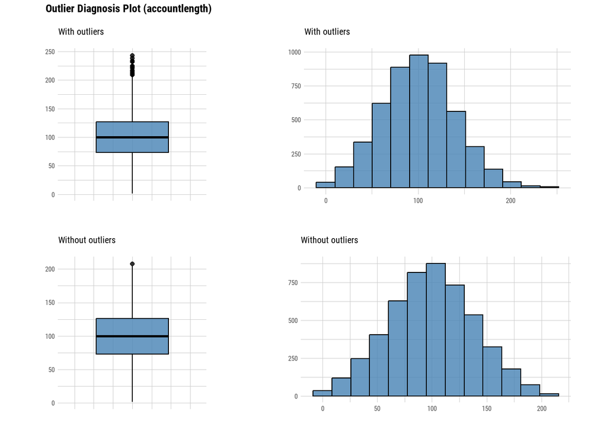

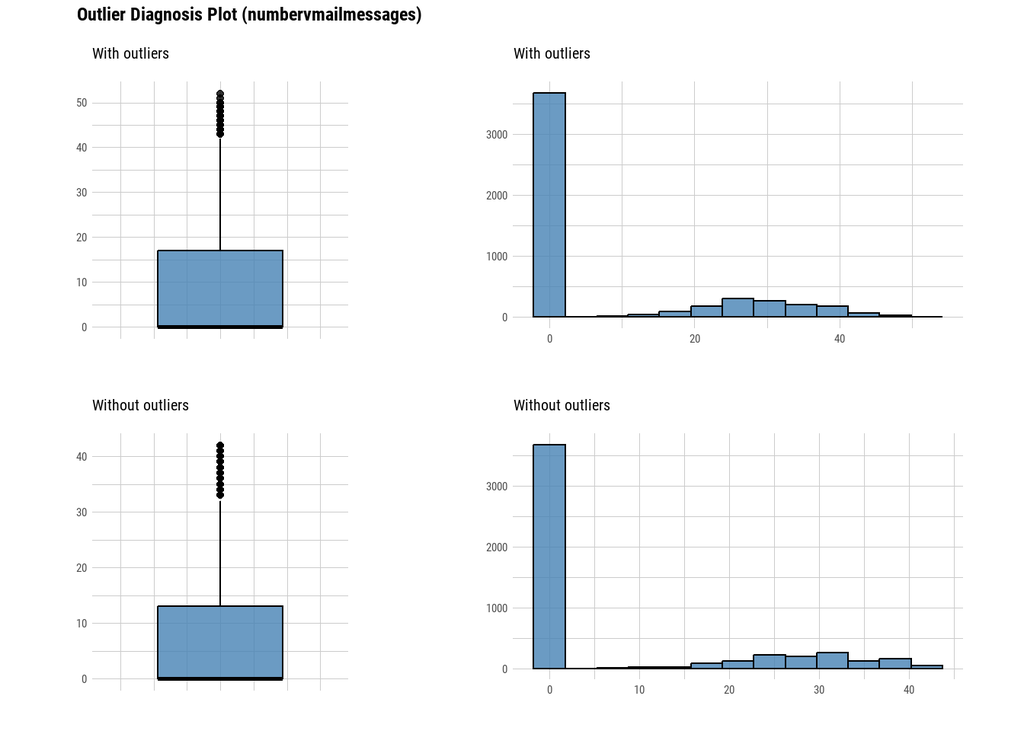

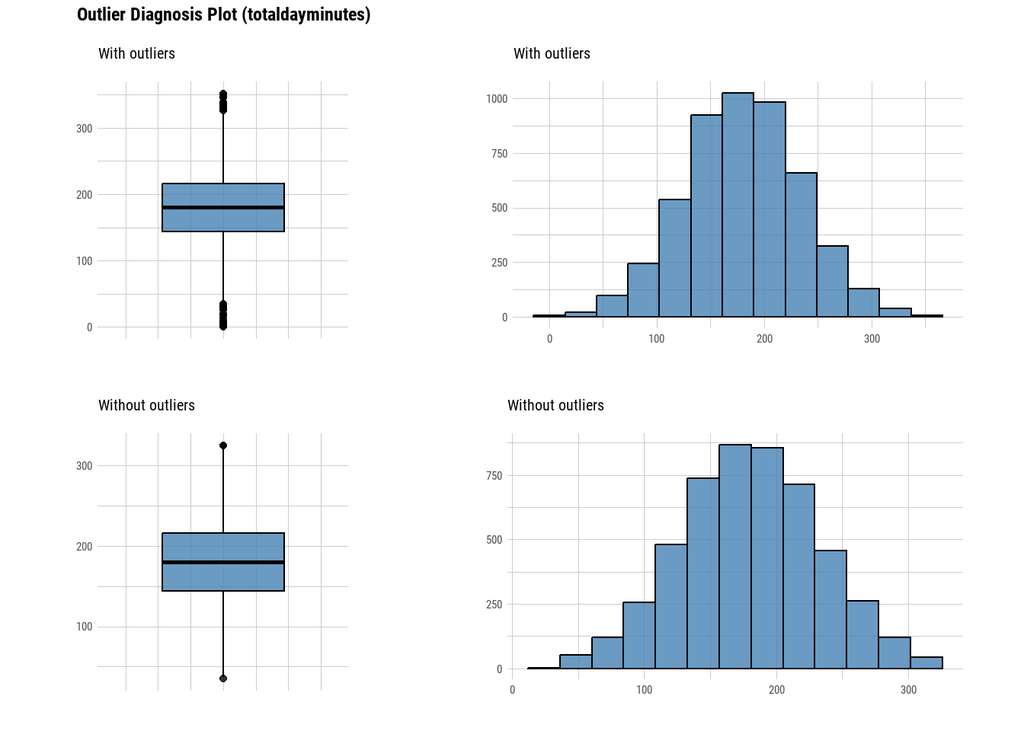

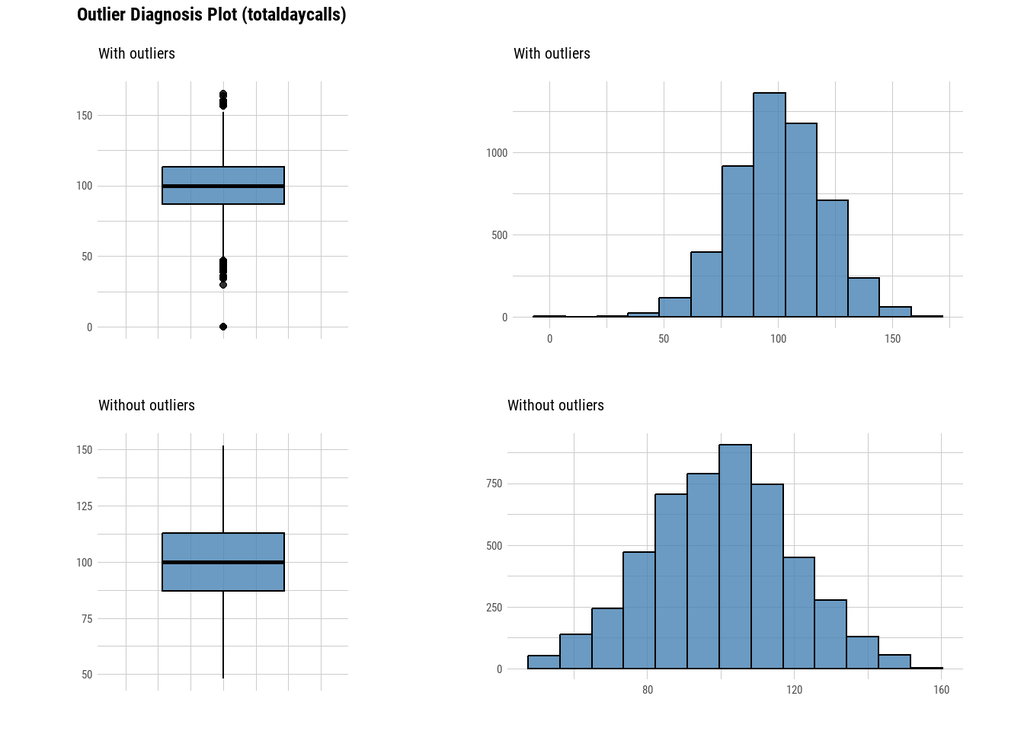

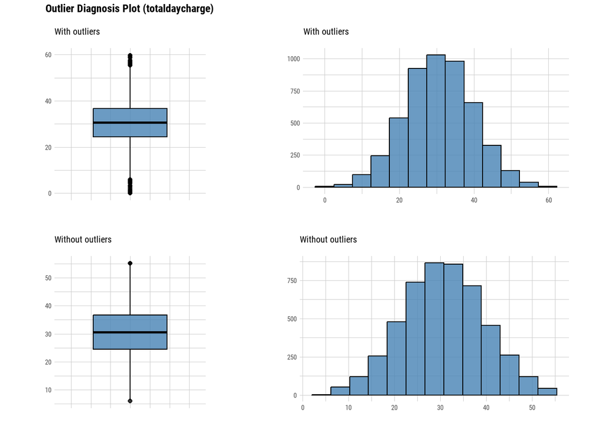

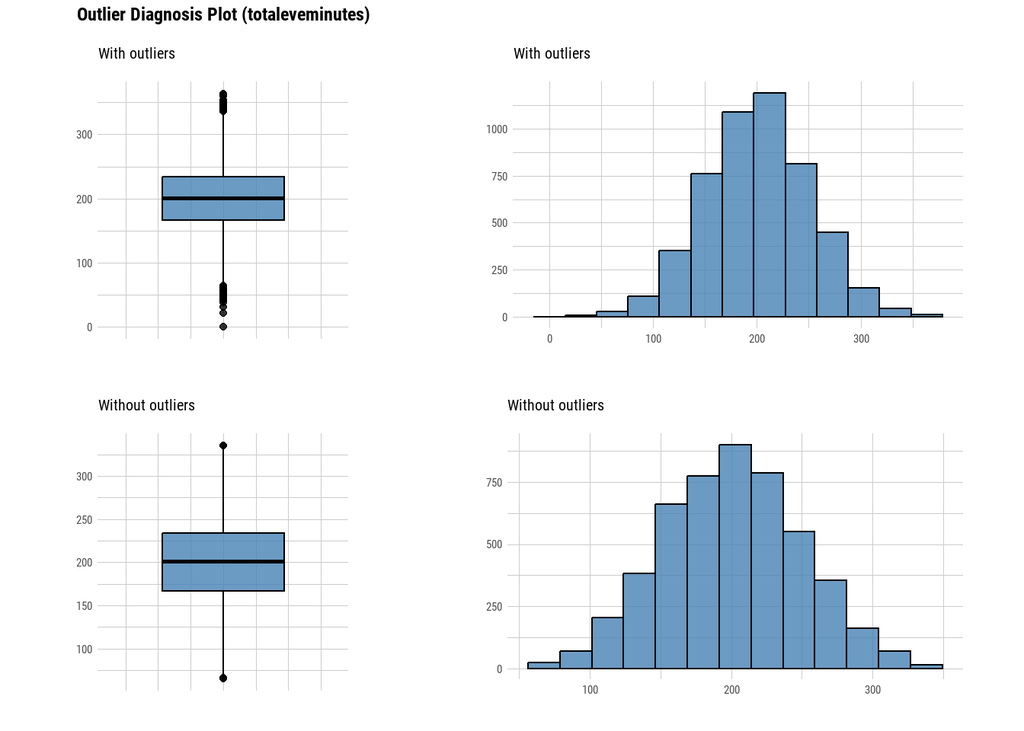

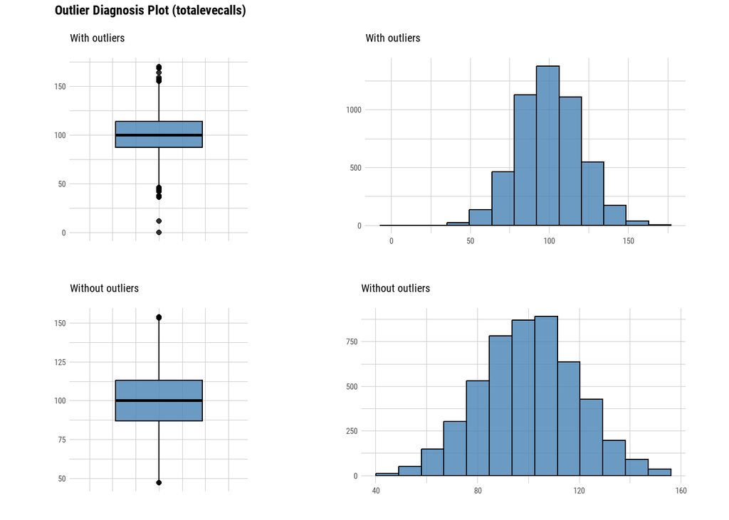

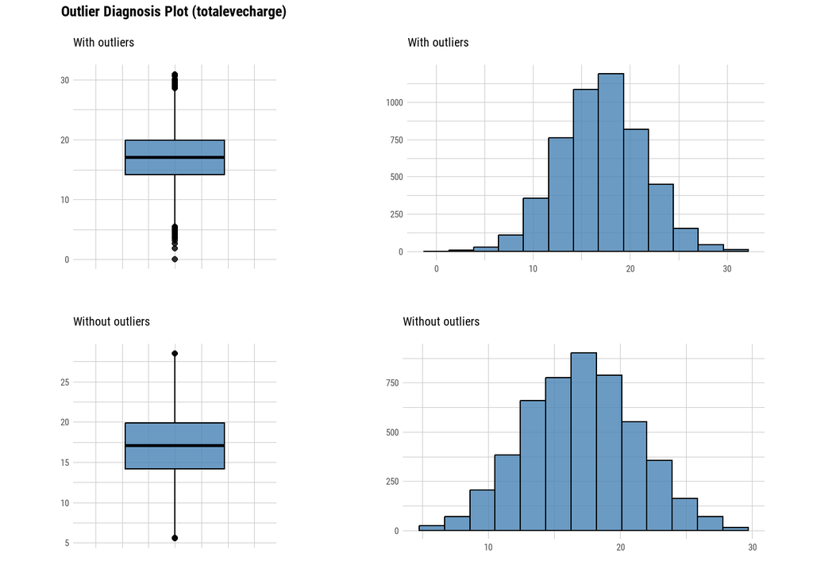

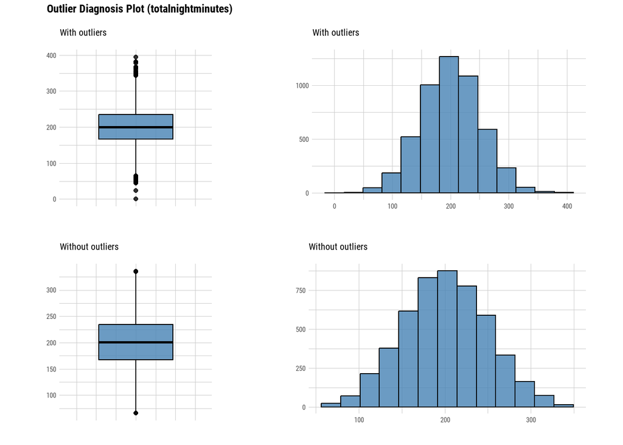

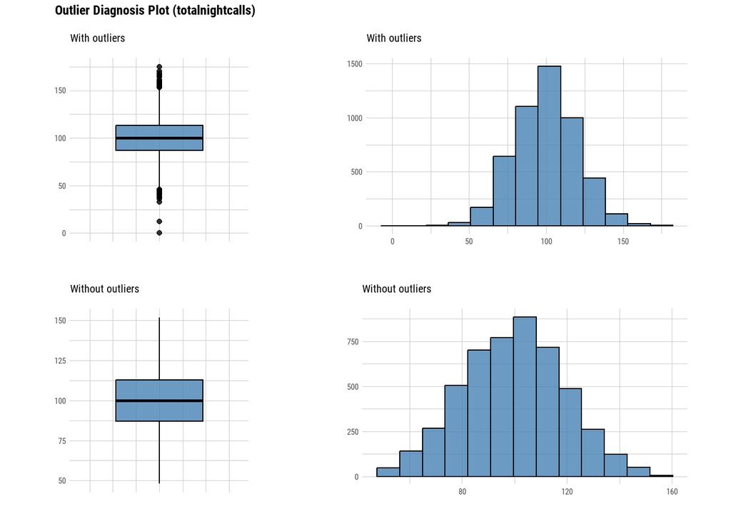

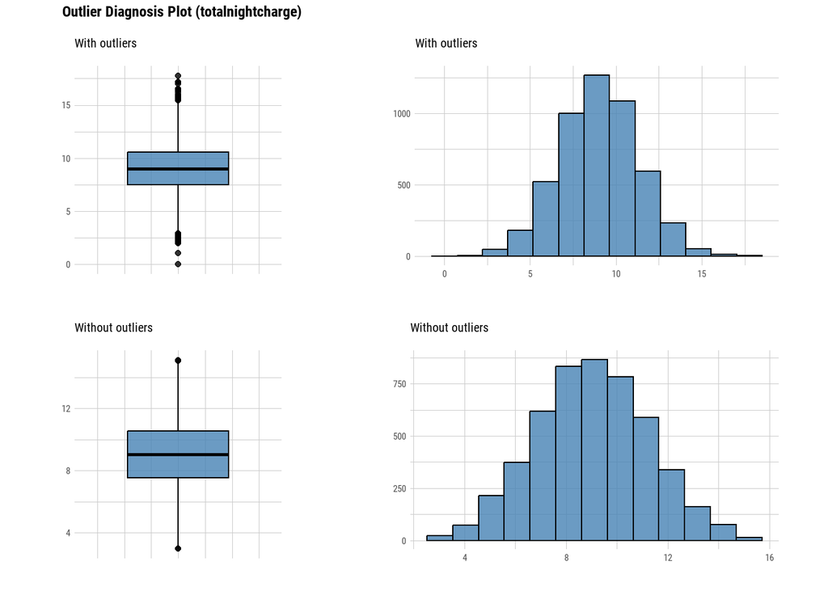

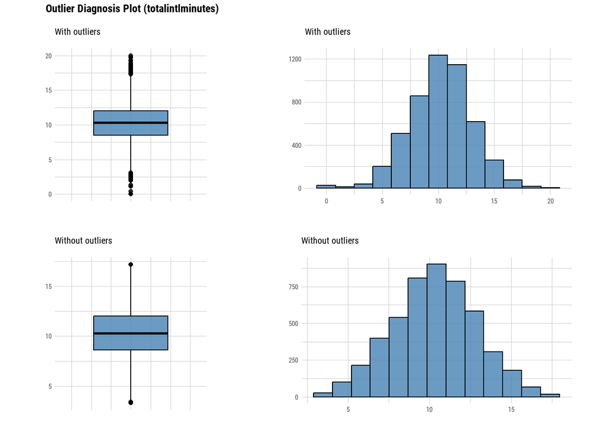

[3 more figures not shown]

```r
df %>%
  select(find_outliers(df)) %>%
  plot_outlier()
```

Outlier diagnosis reveals a minimal impact on the means of all numeric variables, even when outliers are included. Therefore, imputation of outliers is deemed unnecessary.

## Descriptive statistics

```r
dlookr::describe(df) %>%
  flextable()
```

| described_variables | n | na | mean | sd | se_mean | IQR | skewness | kurtosis | p00 | p01 | p05 | p10 | p20 | p25 | p30 | p40 | p50 | p60 | p70 | p75 | p80 | p90 | p95 | p99 | p100 |
| --- | --- | --- | --- | --- | --- | --- | --- | --- | --- | --- | --- | --- | --- | --- | --- | --- | --- | --- | --- | --- | --- | --- | --- | --- | --- |
| accountlength | 5,000 | 0 | 100.258600 | 39.6945595 | 0.56136584 | 54.000 | 0.109291124 | -0.10162108 | 1 | 12.0000 | 35.0000 | 49.000 | 66.80 | 73.000 | 79.000 | 90.000 | 100.00 | 110.00 | 121.00 | 127.00 | 133.00 | 151.100 | 167.0000 | 194.0000 | 243.00 |
| numbervmailmessages | 5,000 | 0 | 7.755200 | 13.5463934 | 0.19157493 | 17.000 | 1.350493197 | 0.19912718 | 0 | 0.0000 | 0.0000 | 0.000 | 0.00 | 0.000 | 0.000 | 0.000 | 0.00 | 0.00 | 0.00 | 17.00 | 24.00 | 32.000 | 37.0000 | 43.0000 | 52.00 |
| totaldayminutes | 5,000 | 0 | 180.288900 | 53.8946992 | 0.76218615 | 72.500 | -0.011730827 | -0.02129447 | 0 | 54.1980 | 91.7000 | 111.890 | 135.40 | 143.700 | 152.070 | 166.660 | 180.10 | 194.00 | 208.70 | 216.20 | 224.90 | 248.810 | 271.1050 | 304.6050 | 351.50 |
| totaldaycalls | 5,000 | 0 | 100.029400 | 19.8311974 | 0.28045548 | 26.000 | -0.084890964 | 0.17856779 | 0 | 54.0000 | 67.0000 | 75.000 | 83.00 | 87.000 | 90.000 | 95.000 | 100.00 | 105.00 | 110.00 | 113.00 | 117.00 | 125.000 | 133.0000 | 146.0000 | 165.00 |
| totaldaycharge | 5,000 | 0 | 30.649668 | 9.1620687 | 0.12957122 | 12.320 | -0.011729007 | -0.02116593 | 0 | 9.2097 | 15.5900 | 19.019 | 23.02 | 24.430 | 25.854 | 28.332 | 30.62 | 32.98 | 35.48 | 36.75 | 38.23 | 42.301 | 46.0905 | 51.7809 | 59.76 |
| totaleveminutes | 5,000 | 0 | 200.636560 | 50.5513090 | 0.71490347 | 67.725 | -0.011017695 | 0.05137513 | 0 | 80.6000 | 118.4950 | 136.700 | 158.90 | 166.375 | 173.300 | 188.000 | 201.00 | 213.20 | 226.30 | 234.10 | 242.80 | 265.320 | 283.7200 | 318.8020 | 363.70 |
| totalevecalls | 5,000 | 0 | 100.191000 | 19.8264958 | 0.28038899 | 27.000 | -0.020175203 | 0.11736340 | 0 | 54.0000 | 67.0000 | 75.000 | 84.00 | 87.000 | 90.000 | 95.000 | 100.00 | 105.00 | 110.00 | 114.00 | 117.00 | 125.000 | 133.0000 | 147.0000 | 170.00 |
| totalevecharge | 5,000 | 0 | 17.054322 | 4.2968433 | 0.06076654 | 5.760 | -0.010990328 | 0.05128879 | 0 | 6.8500 | 10.0695 | 11.620 | 13.51 | 14.140 | 14.730 | 15.980 | 17.09 | 18.12 | 19.24 | 19.90 | 20.64 | 22.552 | 24.1120 | 27.1002 | 30.91 |
| totalnightminutes | 5,000 | 0 | 200.391620 | 50.5277893 | 0.71457085 | 67.800 | 0.019324917 | 0.08235920 | 0 | 81.5950 | 117.3950 | 135.900 | 157.80 | 166.900 | 173.800 | 187.700 | 200.40 | 213.40 | 227.03 | 234.70 | 243.10 | 263.900 | 283.4050 | 318.0030 | 395.00 |
| totalnightcalls | 5,000 | 0 | 99.919200 | 19.9586859 | 0.28225844 | 26.000 | 0.002132843 | 0.14443808 | 0 | 54.9900 | 67.0000 | 74.000 | 83.00 | 87.000 | 90.000 | 95.000 | 100.00 | 105.00 | 110.00 | 113.00 | 117.00 | 125.000 | 132.0000 | 148.0000 | 175.00 |
| totalnightcharge | 5,000 | 0 | 9.017732 | 2.2737627 | 0.03215586 | 3.050 | 0.019286744 | 0.08237762 | 0 | 3.6698 | 5.2800 | 6.120 | 7.10 | 7.510 | 7.820 | 8.450 | 9.02 | 9.60 | 10.22 | 10.56 | 10.94 | 11.880 | 12.7505 | 14.3101 | 17.77 |
| totalintlminutes | 5,000 | 0 | 10.261780 | 2.7613957 | 0.03905203 | 3.500 | -0.209966293 | 0.65531661 | 0 | 3.5000 | 5.7000 | 6.800 | 8.00 | 8.500 | 8.900 | 9.700 | 10.30 | 11.00 | 11.60 | 12.00 | 12.50 | 13.700 | 14.7000 | 16.6000 | 20.00 |
| totalintlcalls | 5,000 | 0 | 4.435200 | 2.4567882 | 0.03474423 | 3.000 | 1.360692479 | 3.26818365 | 0 | 1.0000 | 1.0000 | 2.000 | 2.00 | 3.000 | 3.000 | 3.000 | 4.00 | 5.00 | 5.00 | 6.00 | 6.00 | 8.000 | 9.0000 | 12.0100 | 20.00 |
| totalintlcharge | 5,000 | 0 | 2.771196 | 0.7455137 | 0.01054316 | 0.940 | -0.210286115 | 0.65598855 | 0 | 0.9500 | 1.5400 | 1.840 | 2.16 | 2.300 | 2.400 | 2.620 | 2.78 | 2.97 | 3.13 | 3.24 | 3.38 | 3.700 | 3.9700 | 4.4800 | 5.40 |
| numbercustomerservicecalls | 5,000 | 0 | 1.570400 | 1.3063633 | 0.01847477 | 1.000 | 1.042462330 | 1.48109554 | 0 | 0.0000 | 0.0000 | 0.000 | 0.00 | 1.000 | 1.000 | 1.000 | 1.00 | 2.00 | 2.00 | 2.00 | 3.00 | 3.000 | 4.0000 | 6.0000 | 9.00 |

## Normality Test

```r
normality(df) %>%
  mutate(p_value = round(p_value, 6)) %>%
  flextable()
```

| vars | statistic | p_value | sample |
| --- | --- | --- | --- |
| accountlength | 0.9981750 | 0.000014 | 5,000 |
| numbervmailmessages | 0.6091268 | 0.000000 | 5,000 |
| totaldayminutes | 0.9996361 | 0.514726 | 5,000 |
| totaldaycalls | 0.9985798 | 0.000203 | 5,000 |
| totaldaycharge | 0.9996361 | 0.514816 | 5,000 |
| totaleveminutes | 0.9996586 | 0.581005 | 5,000 |
| totalevecalls | 0.9990881 | 0.008810 | 5,000 |
| totalevecharge | 0.9996578 | 0.578598 | 5,000 |
| totalnightminutes | 0.9997496 | 0.845643 | 5,000 |
| totalnightcalls | 0.9990674 | 0.007504 | 5,000 |
| totalnightcharge | 0.9997473 | 0.839958 | 5,000 |
| totalintlminutes | 0.9940689 | 0.000000 | 5,000 |
| totalintlcalls | 0.9022006 | 0.000000 | 5,000 |
| totalintlcharge | 0.9940435 | 0.000000 | 5,000 |
| numbercustomerservicecalls | 0.8798382 | 0.000000 | 5,000 |

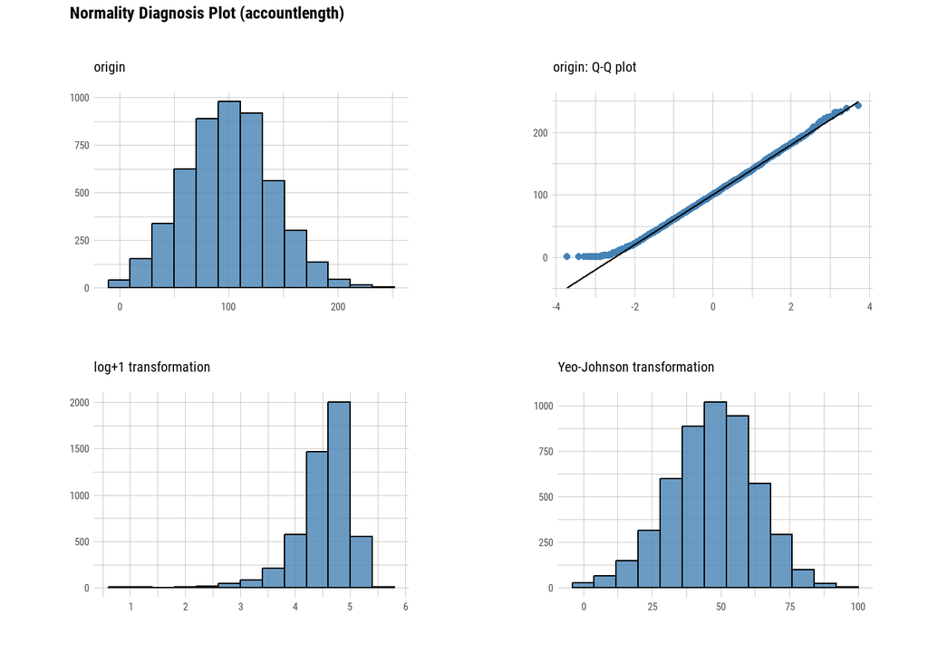

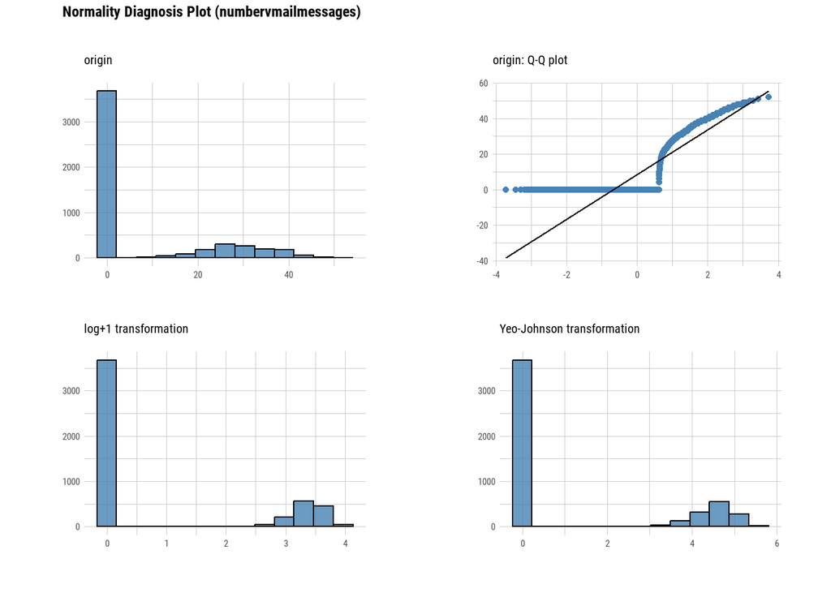

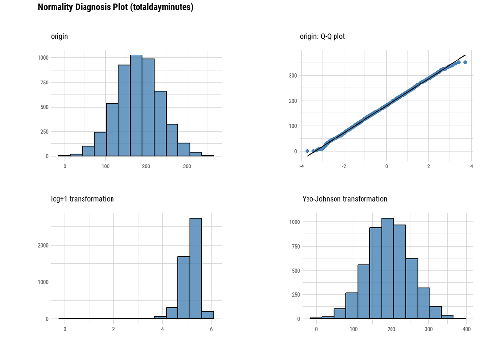

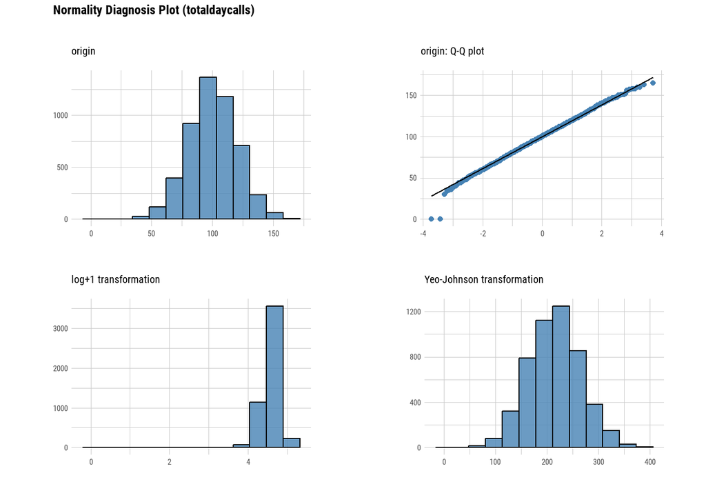

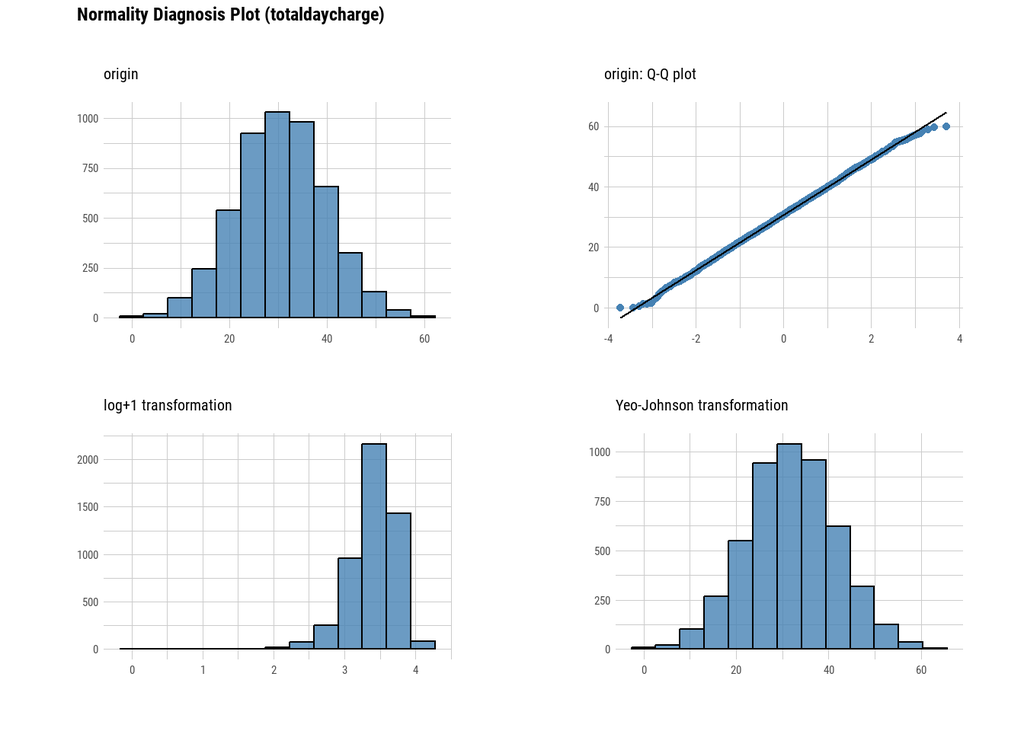

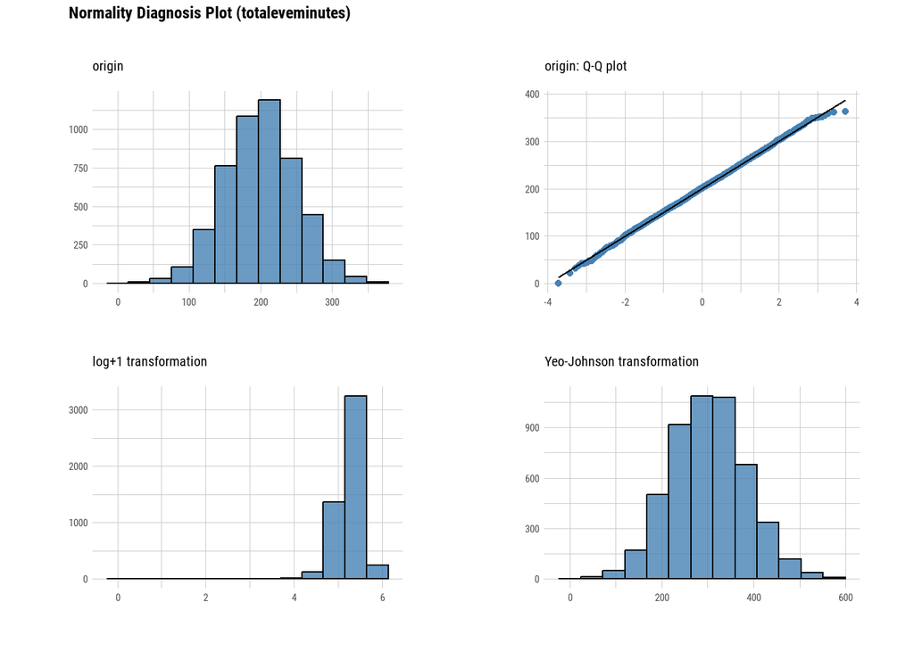

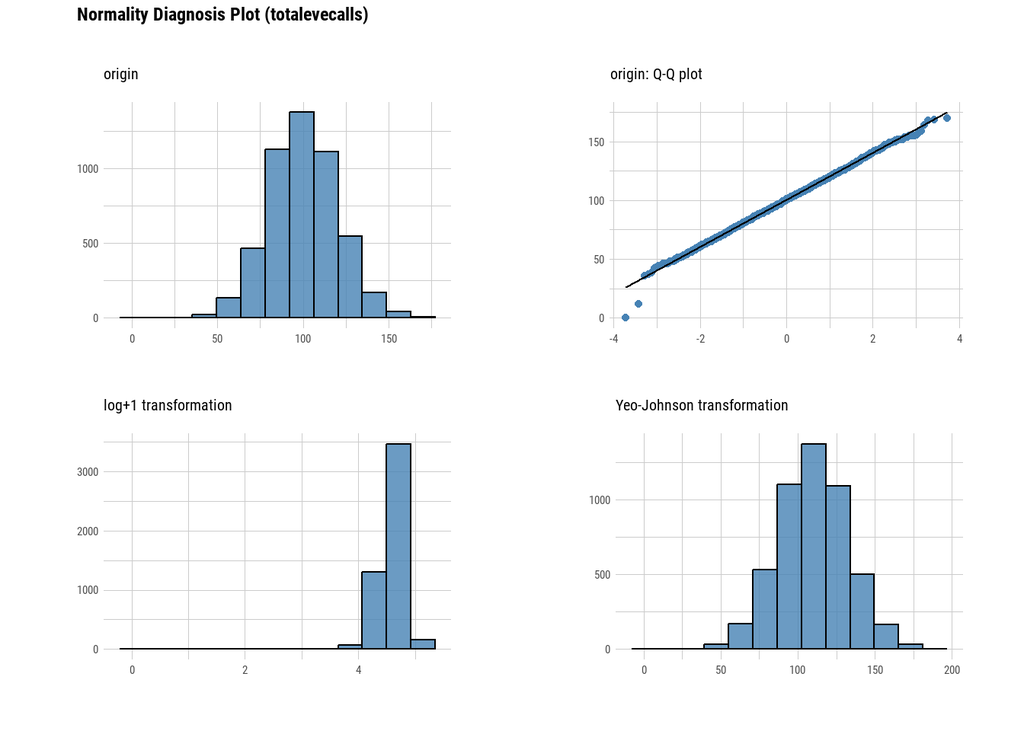

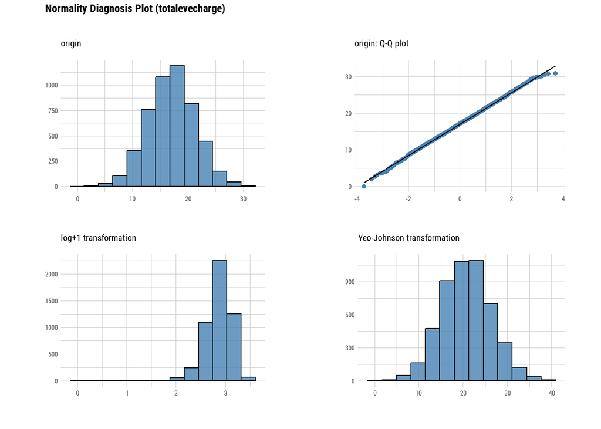

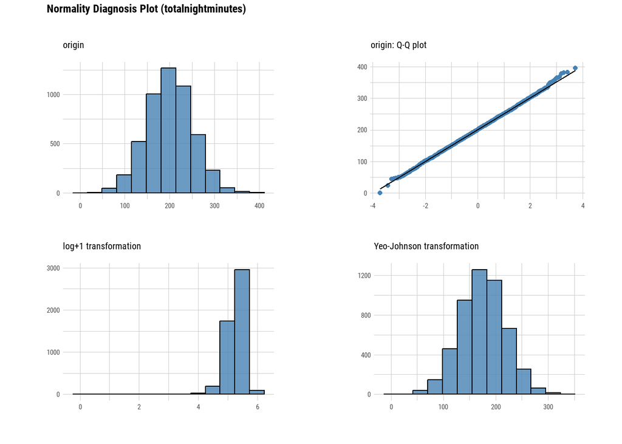

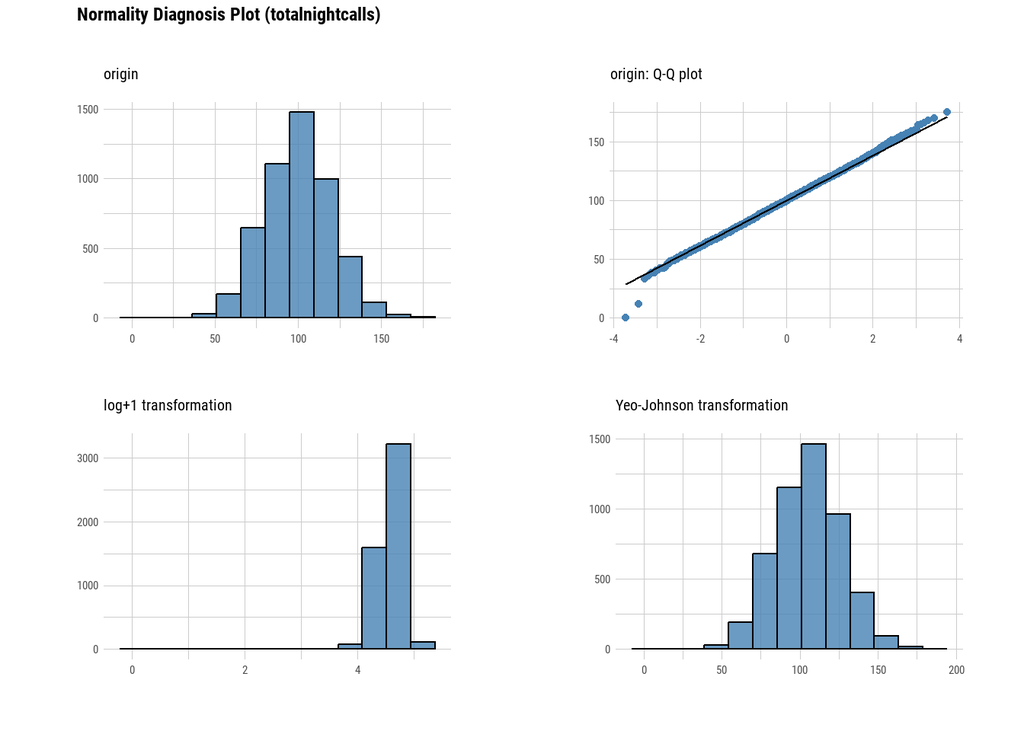

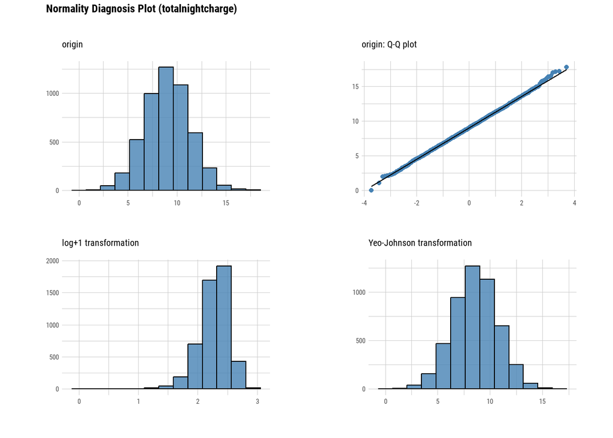

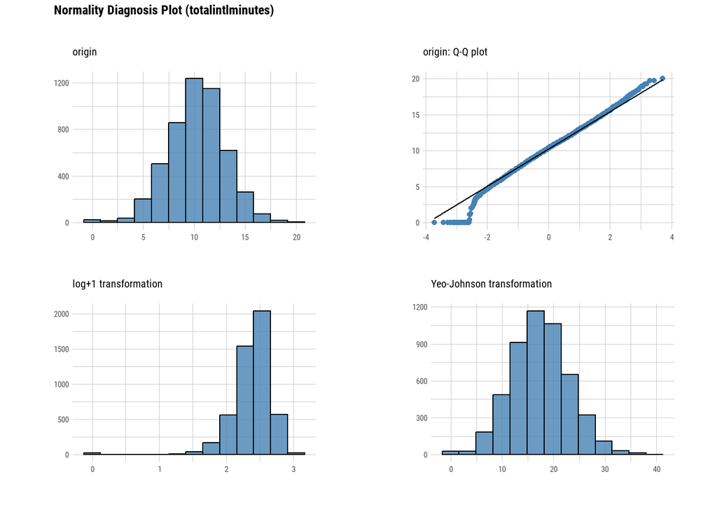

[3 more figures not shown]

```r
df %>%
  plot_normality(colnames(df), left = "log+1", right = "Yeo-Johnson")
```

## Skewness Test

```r
df %>%
  select_if(is.numeric) %>%
  lapply(agostino.test)
```

```
## $accountlength
##
##  D'Agostino skewness test
##
## data:  X[[i]]
## skew = 0.10926, z = 3.14942, p-value = 0.001636
## alternative hypothesis: data have a skewness
##
##
## $numbervmailmessages
##
##  D'Agostino skewness test
##
## data:  X[[i]]
## skew = 1.3501, z = 30.1667, p-value < 2.2e-16
## alternative hypothesis: data have a skewness
##
##
## $totaldayminutes
##
##  D'Agostino skewness test
##
## data:  X[[i]]
## skew = -0.011727, z = -0.339033, p-value = 0.7346
## alternative hypothesis: data have a skewness
##
##
## $totaldaycalls
##
##  D'Agostino skewness test
##
## data:  X[[i]]
## skew = -0.084865, z = -2.449141, p-value = 0.01432
## alternative hypothesis: data have a skewness
##
##
## $totaldaycharge
##
##  D'Agostino skewness test
##
```

[output cut: 78 more lines]

```
##
##  D'Agostino skewness test
##
## data:  X[[i]]
## skew = -0.21022, z = -6.01275, p-value = 1.824e-09
## alternative hypothesis: data have a skewness
##
##
## $numbercustomerservicecalls
##
##  D'Agostino skewness test
##
## data:  X[[i]]
## skew = 1.0421, z = 25.1299, p-value < 2.2e-16
## alternative hypothesis: data have a skewness
```

The results from the normality test indicate that the distributions of certain variables are potentially non-normal. However, the algorithms that will be used for classification do not strictly require the data to follow a normal distribution. Therefore, it is not necessary to apply methods to improve the normality of the distribution in this case.

## Reordering Levels of `churn`

```r
df$churn <- fct_relevel(df$churn, "Yes")

contrasts(df$churn)
```

```
##     No
## Yes  0
## No   1
```

The `"Yes"` level of the churn variable is reordered to be the first level, as it will serve as the reference level.

## Model Selection and Evaluation

### Splitting Data into Training and Test Sets

```r
split_data <- function(data, size) {
  # Set the seed for random number generation
  set.seed(42)

  # Get the number of rows in the data
  n <- nrow(data)

  # Generate a random sample of row indices for the training data
  id <- sample(1:n, size = size * n)

  # Create the training data by selecting the rows with the sampled indices
  train_data <- data[id, ]

  # Create the test data by selecting the rows not in the training data
  test_data <- data[-id, ]

  # Return a list containing the training and test data
  list(train = train_data, test = test_data)
}
```

```r
splitData <- split_data(df, 0.8)
train_data <- splitData$train
test_data <- splitData$test
```

The `df` dataframe is partitioned into training and testing datasets using an 80/20 split. 80% of the data is randomly allocated to the training dataset, while the remaining 20% is assigned to the testing dataset.

### Running Recursive Feature Elimination (RFE) to Select Predictive Variables

```r
run_rfe <- function(data, response, functions, method = "cv", number) {
  # Set the seed for random number generation
  set.seed(12)

  # Define the control using the specified functions, method, and number
  control <- rfeControl(functions = functions, method = method, number = number)

  # Set sizes to 1:(ncol(data)-1)
  sizes <- c(1:(ncol(data)-1))

  # Run the RFE algorithm
  rfe_result <- rfe(data[, !names(data) %in% response],
                    data[[response]], sizes = sizes,
                    rfeControl = control)

  # Summarize results
  print(rfe_result)

}
```

```r
rfe_result  <- run_rfe(train_data, "churn", rfFuncs, number = 10)
```

```
##
## Recursive feature selection
##
## Outer resampling method: Cross-Validated (10 fold)
##
## Resampling performance over subset size:
##
##  Variables Accuracy   Kappa AccuracySD KappaSD Selected
##          1   0.8652 0.16035   0.004350 0.05185
##          2   0.8595 0.07068   0.003613 0.04989
##          3   0.8805 0.26662   0.008882 0.06443
##          4   0.9020 0.52888   0.015569 0.08653
##          5   0.8987 0.52057   0.015101 0.07842
##          6   0.9193 0.62971   0.016846 0.07899
##          7   0.9255 0.66076   0.015942 0.07347
##          8   0.9405 0.72334   0.013086 0.07000
##          9   0.9482 0.76422   0.013676 0.07206
##         10   0.9535 0.79195   0.009789 0.04675
##         11   0.9520 0.78474   0.010580 0.05058
##         12   0.9585 0.81220   0.009317 0.04574
##         13   0.9605 0.82036   0.009358 0.04729        *
##         14   0.9592 0.81471   0.011132 0.05403
##         15   0.9572 0.80374   0.010176 0.05198
##         16   0.9572 0.80688   0.010169 0.04805
##         17   0.9562 0.80162   0.010360 0.04983
##
## The top 5 variables (out of 13):
##    numbercustomerservicecalls, internationalplan, totalintlcalls, totaldayminutes, totaldaycharge
```

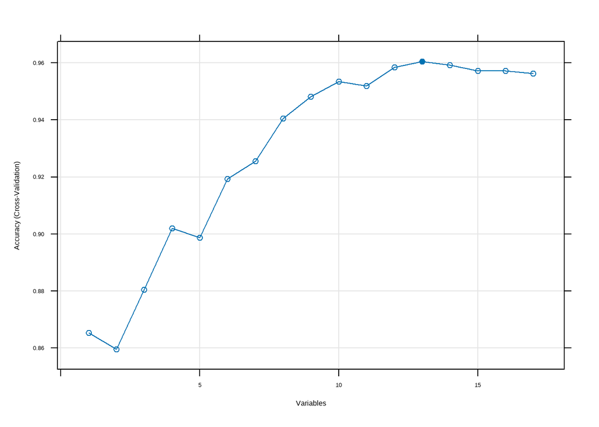

```r
plot(rfe_result, type=c("g", "o"))
```

```r
paste0("The chosen features are: ", paste(rfe_result$optVariables, collapse = ", "))
```

```
## [1] "The chosen features are: numbercustomerservicecalls, internationalplan, totalintlcalls, totaldayminutes, totaldaycharge, totaleveminutes, totalevecharge, voicemailplan, totalintlcharge, numbervmailmessages, totalintlminutes, totalnightminutes, totalnightcharge"
```

The Recursive Feature Elimination (RFE) algorithm is a feature selection technique that recursively removes the least important features from a dataset based on the weights assigned by an external estimator. In this case, a random forest is used as the estimator and 10-fold cross-validation is used to evaluate the performance of the model. The algorithm selected 13 variables as being the most important for predicting customer churn in the given dataset. These variables are: `numbercustomerservicecalls`, `internationalplan`, `totalintlcalls`,`totaldayminutes`, `totaldaycharge`, `totaleveminutes`, `totalevecharge`, `voicemailplan`, `totalintlcharge`, `numbervmailmessages`, `totalintlminutes`, `totalnightminutes`, `totalnightcharge`

### Selecting Specific Columns Based on the Result of Recursive Feature Elimination

```r
subset_train <- train_data %>%
  select(churn,
         numbercustomerservicecalls,
         internationalplan,
         totalintlcalls,
         totaldayminutes,
         totaldaycharge,
         totaleveminutes,
         totalevecharge,
         voicemailplan,
         totalintlcharge,
         numbervmailmessages,
         totalintlminutes,
         totalnightminutes,
         totalnightcharge
         )


subset_test <- test_data %>%
  select(churn,
         numbercustomerservicecalls,
         internationalplan,
         totalintlcalls,
         totaldayminutes,
         totaldaycharge,
         totaleveminutes,
         totalevecharge,
         voicemailplan,
         totalintlcharge,
         numbervmailmessages,
         totalintlminutes,
         totalnightminutes,
         totalnightcharge
         )
```

The `subset_train` and `subset_test` data frame contain the dependent variable churn and the independent variables selected by the Recursive Feature Elimination (RFE) algorithm.

### Proportional Distribution of `churn` in the Training Subset

```r
prop.table(table(subset_train$churn))
```

```
##
##    Yes     No
## 0.1405 0.8595
```

The output shows the proportional distribution of the ‘churn’ variable in the ‘subset_train’ data frame. It indicates that **14.05%** of customers in the training subset have churned (`Yes`), while the majority, **85.95%**, have not (`No`). This suggests that the dataset is imbalanced with respect to the ‘churn’ variable, with a significantly larger proportion of customers not churning.

### Training Multiple Classification Models with Cross-Validation

```r
# Set the seed for random number generation
set.seed(24)

# Set up the control parameters for the training process
ctrl <- trainControl(method = "cv", # Cross-validation method
                     number = 10, # Number of cross-validation folds
                     verboseIter = FALSE, # Do not print iteration log
                     classProbs = TRUE, # Compute class probabilities
                     summaryFunction = prSummary, # Summarize performance of model during resampling
                     savePredictions = "final") # Save final predictions

# Define a list of algorithms to use
algorithmList <- c('rpart', 'glm', 'knn')

# Define a list of tuning parameters for the random forest algorithm
tune_List <- list(rf = caretModelSpec(method="rf",
                                      tuneGrid=data.frame(mtry=2:17)))

# Train multiple models using caretList function
orig_models <- caretList(churn ~ ., # Formula for the model
                     data=subset_train, # Training data
                     metric = "F", # Metric to optimize
                     trControl=ctrl, # Control parameters for training
                     methodList=algorithmList, # List of algorithms to use
                     tuneList=tune_List, # List of tuning parameters
                     preProcess = c("center", "scale")) # Preprocessing steps
```

This analysis utilizes the `caret` package to train a variety of machine learning models for the purpose of predicting a binary outcome variable, `churn`. `A 10-fold cross-validation` procedure is implemented for model training and evaluation, with the final predictions being saved. The models being trained include `rpart` (recursive partitioning and regression trees), `glm` (generalized linear models), and `knn` (k-nearest neighbors), as well as a `random forest (rf)` model with a specified tuning grid for the `mtry` parameter. The training data undergoes pre-processing through centering and scaling of the predictor variables. `F` is used as the performance metric for model selection.

### Evaluating and Comparing the Performance of the Training Multiple Models

```r
# Create a named list to map the names of the models to more descriptive names
name_map1 <- list(rf = "randomForest_orgi",
                  rpart = "decisionTree_orgi",
                  glm = "logistic_orgi",
                  knn = "knn_orgi")

# Rename the models in the orig_models list using the name_map1
names(orig_models) <- name_map1[names(orig_models)]

# Use the resamples function to compute summary statistics for each model
orig_models_result <- resamples(orig_models)

# Compute summary statistics for the models' results
orig_models_result_summary <- summary(orig_models_result)

# Print the summary statistics for the models' results
orig_models_result_summary
```

```
##
## Call:
## summary.resamples(object = orig_models_result)
##
## Models: randomForest_orgi, decisionTree_orgi, logistic_orgi, knn_orgi
## Number of resamples: 10
##
## AUC
##                        Min.   1st Qu.    Median      Mean   3rd Qu.      Max.
## randomForest_orgi 0.7973187 0.8285596 0.8404797 0.8529753 0.8883494 0.9069021
## decisionTree_orgi 0.3522048 0.3922733 0.5108237 0.5021665 0.5928266 0.6536534
## logistic_orgi     0.3283495 0.4114500 0.4420494 0.4369521 0.4670667 0.5403490
## knn_orgi          0.5391665 0.5926848 0.6277449 0.6244475 0.6649410 0.7203894
##                   NA's
## randomForest_orgi    0
## decisionTree_orgi    0
## logistic_orgi        0
## knn_orgi             0
##
## F
##                        Min.   1st Qu.    Median      Mean   3rd Qu.      Max.
## randomForest_orgi 0.7741935 0.8217308 0.8457426 0.8459015 0.8745648 0.9158879
## decisionTree_orgi 0.4523810 0.5278963 0.5812035 0.6086204 0.7139321 0.7500000
## logistic_orgi     0.2089552 0.2741313 0.2984245 0.2963762 0.3248311 0.3703704
## knn_orgi          0.4615385 0.6068975 0.6153846 0.6026346 0.6312325 0.6593407
##                   NA's
## randomForest_orgi    0
## decisionTree_orgi    0
## logistic_orgi        0
## knn_orgi             0
##
## Precision
##                        Min.   1st Qu.    Median      Mean   3rd Qu.      Max.
## randomForest_orgi 0.8888889 0.9241310 0.9483660 0.9421080 0.9688602 0.9800000
## decisionTree_orgi 0.6785714 0.8055556 0.8286867 0.8059189 0.8442928 0.8750000
## logistic_orgi     0.3913043 0.5426136 0.5941176 0.5764785 0.6363636 0.7142857
## knn_orgi          0.8000000 0.8245436 0.8361607 0.8558286 0.8642857 0.9642857
##                   NA's
## randomForest_orgi    0
## decisionTree_orgi    0
## logistic_orgi        0
## knn_orgi             0
##
## Recall
##                        Min.   1st Qu.    Median      Mean   3rd Qu.      Max.
## randomForest_orgi 0.6428571 0.7333177 0.7678571 0.7703634 0.8258929 0.8596491
## decisionTree_orgi 0.3392857 0.3928571 0.4464286 0.4994674 0.6356516 0.6842105
## logistic_orgi     0.1250000 0.1762218 0.2142857 0.2028195 0.2276786 0.2678571
## knn_orgi          0.3214286 0.4642857 0.4779135 0.4679198 0.4978070 0.5357143
##                   NA's
## randomForest_orgi    0
## decisionTree_orgi    0
## logistic_orgi        0
## knn_orgi             0
```

```r
train_performance <- function(sum_models_result) {
  metrics <- c("AUC", "F", "Precision", "Recall")

  # Initialize an empty dataframe
  df <- data.frame()

  # Loop through each metric and bind the results to the dataframe
  for(metric in metrics){
    temp_df <- data.frame(Model = names(sum_models_result$statistics[[metric]][,"Mean"]),
                          Metric = metric,
                          Mean = sum_models_result$statistics[[metric]][,"Mean"])
    df <- rbind(df, temp_df)
  }

  # Reshape the dataframe from long to wide format using the 'reshape()' function
  df_final <- reshape(df, idvar = "Model", timevar = "Metric", direction = "wide")

  # Remove row names
  row.names(df_final) <- NULL

  # Remove 'Mean.' prefix from column names
  names(df_final) <- gsub("Mean.", "", names(df_final))

  # Sort the dataframe by the "F" metric in descending order
  df_final <- df_final[order(df_final$F, decreasing = TRUE), ]

  # Return the final dataframe without row names
  return(df_final)
}
```

```r
train_perform_orgi <- train_performance(orig_models_result_summary)
```

The `train_performance` function is applied to extract the principal performance metrics achieved by each model throughout the training phase. The outcomes, referred to as `train_perform_orgi`, are displayed in a structured table format. This table provides key performance metrics including `"AUC"`, `"F"`, `"Precision"`, and `"Recall"` for each model.

### Generating and Evaluating Predictions for Testing Multiple Models

```r
generate_predictions <- function(models, test_data) {
  # Generate predictions for each model on the test dataset
  predictions <- lapply(names(models), function(model_name) {
    # Get the model object from the models list
    model <- models[[model_name]]

    # Use the predict function to generate predictions for the test dataset
    predicted <- predict(model, newdata = test_data)

    # Return the predictions
    predicted
  })

  # Set the names of the predictions list to match the names of the models
  names(predictions) <- names(models)

  # Return the list of predictions
  predictions
}
```

```r
evaluate_predictions_df <- function(predictions, observed, positive) {
  # Calculate the performance metrics for each set of predictions
  metrics <- sapply(names(predictions), function(model_name) {
    # Get the predictions for the current model
    predicted <- predictions[[model_name]]

    # Calculate the confusion matrix for the current model's predictions
    cm <- confusionMatrix(predicted, observed, positive = positive, mode = "prec_recall")

    # Extract the performance metrics from the confusion matrix
    c(Accuracy = cm$overall["Accuracy"],
      F1 = cm$byClass["F1"],
      Precision = cm$byClass["Precision"],
      Recall = cm$byClass["Recall"])
  })

  # Create a data frame containing the model names and performance metrics
  df <- data.frame(Model = names(predictions), t(metrics))

  # Rename the columns to use shorter names
  colnames(df) <- c("Model", "Accuracy", "F1", "Precision", "Recall")

  # Sort the data frame by F1 score in descending order
  df <- df[order(df$F1, decreasing = TRUE), ]

  # Reset the row names of the data frame
  row.names(df) <- NULL

  # Return the resulting data frame
  df
}
```

```r
# Generate predictions for each model in orig_models on subset_test
predictions_orgi <- generate_predictions(orig_models, subset_test)

# Extract the predictions for each individual model
p_rf_orgi <- predictions_orgi[["randomForest_orgi"]]
p_knn_orgi <- predictions_orgi[["knn_orgi"]]
p_tree_orgi <- predictions_orgi[["decisionTree_orgi"]]
p_logit_orgi <- predictions_orgi[["logistic_orgi"]]

# Create a list of the extracted predictions with new names
cm_pred1 <- list(randomForest_orgi_test = p_rf_orgi,
                 knn_orgi_test = p_knn_orgi ,
                 decisionTree_orgi_test = p_tree_orgi,
                 logistic_orgi_test = p_logit_orgi)
```

```r
test_perform_orgi <- evaluate_predictions_df(cm_pred1, subset_test$churn, "Yes")
```

### Models’ Performance Analysis

```r
train_perform_orgi
```

```
##               Model       AUC         F Precision    Recall
## 1 randomForest_orgi 0.8529753 0.8459015 0.9421080 0.7703634
## 2 decisionTree_orgi 0.5021665 0.6086204 0.8059189 0.4994674
## 4          knn_orgi 0.6244475 0.6026346 0.8558286 0.4679198
## 3     logistic_orgi 0.4369521 0.2963762 0.5764785 0.2028195
```

```r
test_perform_orgi
```

```
##                    Model Accuracy        F1 Precision    Recall
## 1 randomForest_orgi_test    0.963 0.8624535 0.9354839 0.8000000
## 2          knn_orgi_test    0.924 0.6695652 0.9058824 0.5310345
## 3 decisionTree_orgi_test    0.904 0.5596330 0.8356164 0.4206897
## 4     logistic_orgi_test    0.864 0.3200000 0.5818182 0.2206897
```

The results indicate that the `randomForest_orgi` model performs the best in both training and testing phases, based on the F and F1 scores. In the training phase, `randomForest_orgi` has the highest F score of 0.8459015, indicating a good balance between precision and recall. Similarly, in the testing phase, `randomForest_orgi_test` achieves the highest F1 score of 0.8624535, further confirming its superior performance.

On the other hand, `logistic_orgi` and `logistic_orgi_test` have the lowest F and F1 scores respectively in both phases, suggesting that these models may not be as effective in balancing precision and recall.

The `knn_orgi` and `decisionTree_orgi` models show moderate performance. Despite having lower F scores in the training phase compared to `randomForest_orgi`, they still demonstrate reasonable effectiveness.

In summary, these results suggest that the `randomForest_orgi` model is likely to be the most effective choice for this particular task, given its superior performance in both training and testing phases.

### Training Weighted Classification Models with Cross-Validation

```r
# Calculate the weights for each class in the target variable 'churn'
model_weights <- ifelse(subset_train$churn == "Yes",
                        (1/table(subset_train$churn)[1]) * 0.5,
                        (1/table(subset_train$churn)[2]) * 0.5)

# Use the same seed to ensure same cross-validation splits
ctrl$seeds <- orig_models$control$seeds

# Build weighted models using caretList function
weighted_models <- caretList(churn ~ ., # Formula for the model
                     data=subset_train, # Training data
                     metric = "F", # Metric to optimize
                     trControl=ctrl, # Control parameters for training
                     methodList=algorithmList, # List of algorithms to use
                     tuneList=tune_List, # List of tuning parameters
                     preProcess = c("center", "scale"), # Preprocessing steps
                     weights = model_weights) # Weights for each class in the target variable
```

The same seed is used to ensure consistency in cross-validation splits between the original and weighted models. The `caretList` function is then used again to train the models, this time with the addition of the `weights` argument. This argument takes the calculated weights and applies them during model training, effectively giving more importance to instances of the minority class. The models being trained remain the same as before - `rpart`, `glm`, `knn`, and `rf` - and they undergo the same pre-processing steps of centering and scaling. The performance metric for model selection continues to be `F`.

### Evaluating and Comparing the Performance of the Training Weighted Models

```r
# Create a named list to map the names of the models to more descriptive names
name_map2 <- list(rf = "randomForest_w",
                  rpart = "decisionTree_w",
                  glm = "logistic_w",
                  knn = "knn_w")

# Rename the models in the weighted_models list using the name_map2
names(weighted_models) <- name_map2[names(weighted_models)]

# Use the resamples function to compute summary statistics for each model
weighted_models_result <- resamples(weighted_models)

# Compute summary statistics for the models' results
weighted_models_result_summary <- summary(weighted_models_result)

# Print the summary statistics for the models' results
weighted_models_result_summary
```

```
##
## Call:
## summary.resamples(object = weighted_models_result)
##
## Models: randomForest_w, decisionTree_w, logistic_w, knn_w
## Number of resamples: 10
##
## AUC
##                     Min.   1st Qu.    Median      Mean   3rd Qu.      Max. NA's
## randomForest_w 0.7977255 0.8280206 0.8502665 0.8536099 0.8845821 0.9045023    0
## decisionTree_w 0.2741749 0.2882830 0.3108404 0.3203192 0.3436756 0.4081052    0
## logistic_w     0.3207102 0.3971538 0.4171160 0.4335795 0.4889142 0.5232762    0
## knn_w          0.5193695 0.5902639 0.6052372 0.5944631 0.6104757 0.6342912    0
##
## F
##                     Min.   1st Qu.    Median      Mean   3rd Qu.      Max. NA's
## randomForest_w 0.7809524 0.8200000 0.8486579 0.8509438 0.8872294 0.9142857    0
## decisionTree_w 0.4971098 0.5461147 0.5722997 0.5684988 0.5824881 0.6369427    0
## logistic_w     0.4338624 0.4634409 0.4759551 0.4773661 0.4935829 0.5411765    0
## knn_w          0.4691358 0.5825427 0.5964696 0.5932404 0.6311189 0.6744186    0
##
## Precision
##                     Min.   1st Qu.    Median      Mean   3rd Qu.      Max. NA's
## randomForest_w 0.8367347 0.9318182 0.9360544 0.9347737 0.9558900 0.9795918    0
## decisionTree_w 0.3675214 0.4317923 0.4360392 0.4428908 0.4697802 0.5000000    0
## logistic_w     0.3082707 0.3327543 0.3491262 0.3480361 0.3556772 0.4070796    0
## knn_w          0.7297297 0.8037037 0.8360215 0.8406514 0.8717672 1.0000000    0
##
## Recall
##                     Min.   1st Qu.    Median      Mean   3rd Qu.      Max. NA's
## randomForest_w 0.6964286 0.7321429 0.7702068 0.7828947 0.8369361 0.8750000    0
## decisionTree_w 0.7192982 0.7678571 0.7857143 0.7971491 0.8348214 0.8771930    0
## logistic_w     0.6785714 0.7401316 0.7500000 0.7615288 0.7972274 0.8214286    0
## knn_w          0.3392857 0.4464286 0.4732143 0.4606516 0.5000000 0.5263158    0
```

```r
train_perform_w <- train_performance(weighted_models_result_summary)
```

### Generating and Evaluating Predictions for Testing Weighted Models

```r
# Generate predictions for each model in weighted_models on subset_test
predictions_w <- generate_predictions(weighted_models, subset_test)

# Extract the predictions for each individual model
p_rf_w <- predictions_w[["randomForest_w"]]
p_knn_w <- predictions_w[["knn_w"]]
p_tree_w <- predictions_w[["decisionTree_w"]]
p_logit_w <- predictions_w[["logistic_w"]]

# Create a list of the extracted predictions with new names
cm_pred2 <- list(randomForest_w_test = p_rf_w,
                 knn_w_test = p_knn_w ,
                 decisionTree_w_test = p_tree_w,
                 logistic_w_test = p_logit_w)
```

```r
test_perform_w <- evaluate_predictions_df(cm_pred2, subset_test$churn, "Yes")
```

### Weighted Models’ Performance Analysis

```r
train_perform_w
```

```
##            Model       AUC         F Precision    Recall
## 1 randomForest_w 0.8536099 0.8509438 0.9347737 0.7828947
## 4          knn_w 0.5944631 0.5932404 0.8406514 0.4606516
## 2 decisionTree_w 0.3203192 0.5684988 0.4428908 0.7971491
## 3     logistic_w 0.4335795 0.4773661 0.3480361 0.7615288
```

```r
test_perform_w
```

```
##                 Model Accuracy        F1 Precision    Recall
## 1 randomForest_w_test    0.964 0.8666667 0.9360000 0.8068966
## 2          knn_w_test    0.924 0.6695652 0.9058824 0.5310345
## 3 decisionTree_w_test    0.826 0.5693069 0.4440154 0.7931034
## 4     logistic_w_test    0.778 0.5131579 0.3762058 0.8068966
```

The results reveal that the `randomForest_w` model exhibits the highest performance in both the training and testing phases, as evidenced by the F and F1 scores. In the training phase, `randomForest_w` achieves the highest F score, indicating a strong balance between precision and recall. This is mirrored in the testing phase, where `randomForest_w_test` secures the highest F1 score, further affirming its robust performance.

Conversely, `logistic_w` and `logistic_w_test` record the lowest F and F1 scores respectively in both phases. This suggests that these models may struggle to effectively balance precision and recall.

The `knn_w` and `decisionTree_w` models demonstrate moderate performance. Despite trailing behind `randomForest_w` in terms of F scores during the training phase, they still exhibit reasonable effectiveness.

In conclusion, these results suggest that for this specific task, the `randomForest_w` model is likely to be the most effective choice given its superior performance in both training and testing phases.

### Training Down-Sampled Classification Models with Cross-Validation

```r
# Use the same seed to ensure same cross-validation splits
ctrl$seeds <- orig_models$control$seeds

# Set the sampling method to 'down' in the control parameters
ctrl$sampling <- "down"

# Build down-sampled models using caretList function
down_models <- caretList(churn ~ ., # Formula for the model
                     data=subset_train, # Training data
                     metric = "F", # Metric to optimize
                     trControl=ctrl, # Control parameters for training
                     methodList=algorithmList, # List of algorithms to use
                     tuneList=tune_List, # List of tuning parameters
                     preProcess = c("center", "scale")) # Preprocessing steps
```

This analysis is an extension of the `orig_models`. The same seed is used to ensure identical cross-validation splits for model reproducibility. A new control parameter, `sampling`, is set to “down” to indicate the use of down-sampling, a technique often used to balance the classes in the training data. This is particularly useful when dealing with imbalanced datasets where one class significantly outnumbers the other.

The `caretList` function is then called again to train the models with the updated control parameters. The models being trained remain the same: `rpart`, `glm`, `knn`, and a `random forest` model with a specified tuning grid for the `mtry` parameter. The training data undergoes the same pre-processing steps of centering and scaling. The performance metric for model selection continues to be `F`. This process results in a new set of models, `down_models`, trained using down-sampling.

### Evaluating and Comparing the Performance of the Training Down-Sampled Models

```r
# Create a named list to map the names of the models to more descriptive names
name_map3 <- list(rf = "randomForest_down",
                  rpart = "decisionTree_down",
                  glm = "logistic_down",
                  knn = "knn_down")

# Rename the models in the down_models list using the name_map3
names(down_models) <- name_map3[names(down_models)]

# Use the resamples function to compute summary statistics for each model
down_models_result <- resamples(down_models)

# Compute summary statistics for the models' results
down_models_result_summary <- summary(down_models_result)

# Print the summary statistics for the models' results
down_models_result_summary
```

```
##
## Call:
## summary.resamples(object = down_models_result)
##
## Models: randomForest_down, decisionTree_down, logistic_down, knn_down
## Number of resamples: 10
##
## AUC
##                        Min.   1st Qu.    Median      Mean   3rd Qu.      Max.
## randomForest_down 0.7125249 0.7805115 0.8155237 0.8033450 0.8402877 0.8528869
## decisionTree_down 0.2629656 0.2838851 0.2954305 0.3019959 0.3224742 0.3438605
## logistic_down     0.3693880 0.3981580 0.4199576 0.4223997 0.4406966 0.5092910
## knn_down          0.4495981 0.4884064 0.5068598 0.5134331 0.5437863 0.5945401
##                   NA's
## randomForest_down    0
## decisionTree_down    0
## logistic_down        0
## knn_down             0
##
## F
##                        Min.   1st Qu.    Median      Mean   3rd Qu.      Max.
## randomForest_down 0.6825397 0.7384935 0.7576794 0.7549638 0.7785477 0.8000000
## decisionTree_down 0.5165563 0.5322920 0.5542712 0.5598512 0.5965578 0.6000000
## logistic_down     0.4046243 0.4644154 0.4695137 0.4746529 0.4990833 0.5291005
## knn_down          0.5277778 0.5984224 0.6254133 0.6211845 0.6575805 0.6758621
##                   NA's
## randomForest_down    0
## decisionTree_down    0
## logistic_down        0
## knn_down             0
##
## Precision
##                        Min.   1st Qu.    Median      Mean   3rd Qu.      Max.
## randomForest_down 0.6142857 0.6566667 0.6805797 0.6846415 0.7107005 0.7619048
## decisionTree_down 0.3884298 0.4105263 0.4350244 0.4329893 0.4558175 0.4700000
## logistic_down     0.2991453 0.3291806 0.3441439 0.3452293 0.3658964 0.3818182
## knn_down          0.4318182 0.4855612 0.5083645 0.5035239 0.5248855 0.5505618
##                   NA's
## randomForest_down    0
## decisionTree_down    0
## logistic_down        0
## knn_down             0
##
## Recall
##                        Min.   1st Qu.    Median      Mean   3rd Qu.      Max.
## randomForest_down 0.7678571 0.8258929 0.8496241 0.8451128 0.8883929 0.8947368
## decisionTree_down 0.6964286 0.7187500 0.8229950 0.7969925 0.8545583 0.9107143
## logistic_down     0.6250000 0.7192982 0.7678571 0.7617168 0.7991071 0.8928571
## knn_down          0.6785714 0.7666823 0.8303571 0.8113409 0.8660714 0.8947368
##                   NA's
## randomForest_down    0
## decisionTree_down    0
## logistic_down        0
## knn_down             0
```

```r
train_perform_down <- train_performance(down_models_result_summary)
```

### Generating and Evaluating Predictions for Testing Down-Sampled Models

```r
# Generate predictions for each model in down_models on subset_test
predictions_down <- generate_predictions(down_models, subset_test)

# Extract the predictions for each individual model
p_rf_down <- predictions_down[["randomForest_down"]]
p_knn_down <- predictions_down[["knn_down"]]
p_tree_down <- predictions_down[["decisionTree_down"]]
p_logit_down <- predictions_down[["logistic_down"]]

# Create a list of the extracted predictions with new names
cm_pred3 <- list(randomForest_down_test = p_rf_down,
                 knn_down_test = p_knn_down ,
                 decisionTree_down_test = p_tree_down,
                 logistic_down_test = p_logit_down)
```

```r
test_perform_down <- evaluate_predictions_df(cm_pred3, subset_test$churn, "Yes")
```

### Down-Sampled Models’ Performance Analysis

```r
train_perform_down
```

```
##               Model       AUC         F Precision    Recall
## 1 randomForest_down 0.8033450 0.7549638 0.6846415 0.8451128
## 4          knn_down 0.5134331 0.6211845 0.5035239 0.8113409
## 2 decisionTree_down 0.3019959 0.5598512 0.4329893 0.7969925
## 3     logistic_down 0.4223997 0.4746529 0.3452293 0.7617168
```

```r
test_perform_down
```

```
##                    Model Accuracy        F1 Precision    Recall
## 1 randomForest_down_test    0.935 0.7909968 0.7409639 0.8482759
## 2          knn_down_test    0.869 0.6579634 0.5294118 0.8689655
## 3 decisionTree_down_test    0.834 0.5786802 0.4578313 0.7862069
## 4     logistic_down_test    0.764 0.4957265 0.3591331 0.8000000
```

The results show that the `randomForest_down` model outperforms the others in both the training and testing phases, as reflected in the F and F1 scores. In the training phase, `randomForest_down` achieves the highest F score, indicating a strong balance between precision and recall. This is further confirmed in the testing phase, where `randomForest_down_test` secures the highest F1 score, reinforcing its robust performance.

In contrast, `logistic_down` and `logistic_down_test` record the lowest F and F1 scores respectively in both phases. This suggests that these models may struggle to effectively balance precision and recall.

The `knn_down` and `decisionTree_down` models demonstrate moderate performance. Despite trailing behind `randomForest_down` in terms of F scores during the training phase, they still exhibit reasonable effectiveness.

In conclusion, these results suggest that for this specific task, the `randomForest_down` model is likely to be the most effective choice given its superior performance in both training and testing phases.

### Training Up-Sampled Classification Models with Cross-Validation

```r
# Use the same seed to ensure same cross-validation splits
ctrl$seeds <- orig_models$control$seeds

# Set the sampling method to 'up' in the control parameters
ctrl$sampling <- "up"

# Build up-sampled models using caretList function
up_models <- caretList(churn ~ ., # Formula for the model
                     data=subset_train, # Training data
                     metric = "F", # Metric to optimize
                     trControl=ctrl, # Control parameters for training
                     methodList=algorithmList, # List of algorithms to use
                     tuneList=tune_List, # List of tuning parameters
                     preProcess = c("center", "scale")) # Preprocessing steps
```

This analysis is an extension of the`orig_models`. The same seed is used to ensure identical cross-validation splits for model reproducibility. A new control parameter, `sampling`, is set to “up” to indicate the use of up-sampling, a technique often used to balance the classes in the training data. This is particularly useful when dealing with imbalanced datasets where one class significantly outnumbers the other.

The `caretList` function is then called again to train the models with the updated control parameters. The models being trained remain the same: `rpart`, `glm`, `knn`, and a `random forest` model with a specified tuning grid for the `mtry` parameter. The training data undergoes the same pre-processing steps of centering and scaling. The performance metric for model selection continues to be `F`. This process results in a new set of models, `up_models`, trained using up-sampling.

### Evaluating and Comparing the Performance of the Training Up-Sampled Models

```r
# Create a named list to map the names of the models to more descriptive names
name_map4 <- list(rf = "randomForest_up",
                  rpart = "decisionTree_up",
                  glm = "logistic_up",
                  knn = "knn_up")

# Rename the models in the up_models list using the name_map4
names(up_models) <- name_map4[names(up_models)]

# Use the resamples function to compute summary statistics for each model
up_models_result <- resamples(up_models)

# Compute summary statistics for the models' results
up_models_result_summary <- summary(up_models_result)

# Print the summary statistics for the models' results
up_models_result_summary
```

```
##
## Call:
## summary.resamples(object = up_models_result)
##
## Models: randomForest_up, decisionTree_up, logistic_up, knn_up
## Number of resamples: 10
##
## AUC
##                      Min.   1st Qu.    Median      Mean   3rd Qu.      Max.
## randomForest_up 0.7899927 0.8299398 0.8543346 0.8447846 0.8666234 0.8758881
## decisionTree_up 0.2909360 0.3055851 0.3146751 0.3181174 0.3294685 0.3565365
## logistic_up     0.2808082 0.4088445 0.4442953 0.4274581 0.4589510 0.5146688
## knn_up          0.1856249 0.2058765 0.2156533 0.2188723 0.2259176 0.2646593
##                 NA's
## randomForest_up    0
## decisionTree_up    0
## logistic_up        0
## knn_up             0
##
## F
##                      Min.   1st Qu.    Median      Mean   3rd Qu.      Max.
## randomForest_up 0.7755102 0.8170698 0.8495575 0.8395612 0.8647247 0.8867925
## decisionTree_up 0.5276074 0.5509635 0.5676548 0.5682660 0.5861946 0.6071429
## logistic_up     0.4269663 0.4581006 0.4780193 0.4777995 0.5034451 0.5251397
## knn_up          0.4395604 0.5204223 0.5281041 0.5243033 0.5355680 0.5766871
##                 NA's
## randomForest_up    0
## decisionTree_up    0
## logistic_up        0
## knn_up             0
##
## Precision
##                      Min.   1st Qu.    Median      Mean   3rd Qu.      Max.
## randomForest_up 0.8421053 0.8736707 0.9174972 0.9075816 0.9393750 0.9565217
## decisionTree_up 0.4018692 0.4291489 0.4477124 0.4404323 0.4538899 0.4594595
## logistic_up     0.3114754 0.3333333 0.3452621 0.3489875 0.3678862 0.3879310
## knn_up          0.3174603 0.3809524 0.3900372 0.3878551 0.4004796 0.4433962
##                 NA's
## randomForest_up    0
## decisionTree_up    0
## logistic_up        0
## knn_up             0
##
## Recall
##                      Min.   1st Qu.    Median      Mean   3rd Qu.      Max.
## randomForest_up 0.6607143 0.7321429 0.8125000 0.7862469 0.8414004 0.8596491
## decisionTree_up 0.7142857 0.7723214 0.7857143 0.8021930 0.8348214 0.8947368
## logistic_up     0.6785714 0.7321429 0.7678571 0.7578634 0.7885338 0.8392857
## knn_up          0.7142857 0.7723214 0.8229950 0.8112155 0.8571429 0.8947368
##                 NA's
## randomForest_up    0
## decisionTree_up    0
## logistic_up        0
## knn_up             0
```

```r
train_perform_up <- train_performance(up_models_result_summary)
```

### Generating and Evaluating Predictions for Testing Up-Sampled Models

```r
# Generate predictions for each model in up_models on subset_test
predictions_up <- generate_predictions(up_models, subset_test)

# Extract the predictions for each individual model
p_rf_up <- predictions_up[["randomForest_up"]]
p_knn_up <- predictions_up[["knn_up"]]
p_tree_up <- predictions_up[["decisionTree_up"]]
p_logit_up <- predictions_up[["logistic_up"]]

# Create a list of the extracted predictions with new names
cm_pred4 <- list(randomForest_up_test = p_rf_up,
                 knn_up_test = p_knn_up ,
                 decisionTree_up_test = p_tree_up,
                 logistic_up_test = p_logit_up)
```

```r
test_perform_up <- evaluate_predictions_df(cm_pred4, subset_test$churn, "Yes")
```

### Up-Sampled Models’ Performance Analysis

```r
train_perform_up
```

```
##             Model       AUC         F Precision    Recall
## 1 randomForest_up 0.8447846 0.8395612 0.9075816 0.7862469
## 2 decisionTree_up 0.3181174 0.5682660 0.4404323 0.8021930
## 4          knn_up 0.2188723 0.5243033 0.3878551 0.8112155
## 3     logistic_up 0.4274581 0.4777995 0.3489875 0.7578634
```

```r
test_perform_up
```

```
##                  Model Accuracy        F1 Precision    Recall
## 1 randomForest_up_test    0.959 0.8487085 0.9126984 0.7931034
## 2 decisionTree_up_test    0.832 0.5757576 0.4541833 0.7862069
## 3          knn_up_test    0.811 0.5614849 0.4230769 0.8344828
## 4     logistic_up_test    0.776 0.5130435 0.3746032 0.8137931
```

The results demonstrate that the `randomForest_up` model delivers the strongest performance in both the training and testing phases, as indicated by the F and F1 scores. In the training phase, `randomForest_up` records the highest F score, suggesting a robust balance between precision and recall. This is further corroborated in the testing phase, where `randomForest_up_test` achieves the highest F1 score, reinforcing its superior performance.

In contrast, `logistic_up` and `logistic_up_test` register the lowest F and F1 scores respectively in both phases. This implies that these models may face challenges in effectively balancing precision and recall.

The `knn_up` and `decisionTree_up` models display moderate performance. Despite having lower F scores in the training phase compared to `randomForest_up`, they still exhibit reasonable effectiveness.

In conclusion, these results suggest that for this specific task, the `randomForest_up` model is likely to be the most effective choice given its superior performance in both training and testing phases.

### Training SMOTE-Sampled Classification Models with Cross-Validation

```r
# Use the same seed to ensure same cross-validation splits
ctrl$seeds <- orig_models$control$seeds

# Set the sampling method to 'smote' in the control parameters
ctrl$sampling <- "smote"

# Build SMOTE-sampled models using caretList function
smote_models <- caretList(churn ~ ., # Formula for the model
                     data=subset_train, # Training data
                     metric = "F", # Metric to optimize
                     trControl=ctrl, # Control parameters for training
                     methodList=algorithmList, # List of algorithms to use
                     tuneList=tune_List, # List of tuning parameters
                     preProcess = c("center", "scale")) # Preprocessing steps
```

This analysis is an extension of the `orig_models`. The same seed is used to ensure identical cross-validation splits for model reproducibility. A new control parameter, `sampling`, is set to “smote” to indicate the use of Synthetic Minority Over-sampling Technique (SMOTE), a popular technique for addressing class imbalance by generating synthetic examples in the feature space.

The `caretList` function is then called again to train the models with the updated control parameters. The models being trained remain the same: `rpart`, `glm`, `knn`, and a `random forest` model with a specified tuning grid for the `mtry` parameter. The training data undergoes the same pre-processing steps of centering and scaling. The performance metric for model selection continues to be `F`. This process results in a new set of models, `smote_models`, trained using SMOTE.

### Evaluating and Comparing the Performance of the Training SMOTE-Sampled Models

```r
# Create a named list to map the names of the models to more descriptive names
name_map5 <- list(rf = "randomForest_smote",
                  rpart = "decisionTree_smote",
                  glm = "logistic_smote",
                  knn = "knn_smote")

# Rename the models in the smote_models list using the name_map5
names(smote_models) <- name_map5[names(smote_models)]

# Use the resamples function to compute summary statistics for each model
smote_models_result <- resamples(smote_models)

# Compute summary statistics for the models' results
smote_models_result_summary <- summary(smote_models_result)

# Print the summary statistics for the models' results
smote_models_result_summary
```

```
##
## Call:
## summary.resamples(object = smote_models_result)
##
## Models: randomForest_smote, decisionTree_smote, logistic_smote, knn_smote
## Number of resamples: 10
##
## AUC
##                         Min.   1st Qu.    Median      Mean   3rd Qu.      Max.
## randomForest_smote 0.7252692 0.7494241 0.7732202 0.7849212 0.8194948 0.8789079
## decisionTree_smote 0.2558066 0.2643811 0.2932165 0.2861125 0.3001015 0.3182043
## logistic_smote     0.3584204 0.3834730 0.4353254 0.4306424 0.4613013 0.5520631
## knn_smote          0.3377644 0.3725210 0.3920468 0.4094022 0.4495044 0.5005397
##                    NA's
## randomForest_smote    0
## decisionTree_smote    0
## logistic_smote        0
## knn_smote             0
##
## F
##                         Min.   1st Qu.    Median      Mean   3rd Qu.      Max.
## randomForest_smote 0.7850467 0.8198932 0.8380365 0.8398054 0.8683741 0.9026549
## decisionTree_smote 0.5341615 0.5576025 0.5685520 0.5697386 0.5811005 0.6144578
## logistic_smote     0.4419890 0.4473893 0.4706489 0.4756760 0.4920992 0.5581395
## knn_smote          0.5490196 0.5700723 0.5874810 0.5993430 0.6268575 0.6808511
##                    NA's
## randomForest_smote    0
## decisionTree_smote    0
## logistic_smote        0
## knn_smote             0
##
## Precision
##                         Min.   1st Qu.    Median      Mean   3rd Qu.      Max.
## randomForest_smote 0.8235294 0.8664466 0.8866310 0.8777940 0.9015688 0.9148936
## decisionTree_smote 0.4095238 0.4254107 0.4444826 0.4401075 0.4555492 0.4636364
## logistic_smote     0.3225806 0.3290732 0.3468210 0.3502514 0.3625000 0.4137931
## knn_smote          0.4313725 0.4431273 0.4832517 0.4834149 0.5079087 0.5647059
##                    NA's
## randomForest_smote    0
## decisionTree_smote    0
## logistic_smote        0
## knn_smote             0
##
## Recall
##                         Min.   1st Qu.    Median      Mean   3rd Qu.      Max.
## randomForest_smote 0.7500000 0.7678571 0.7946429 0.8059211 0.8356046 0.9107143
## decisionTree_smote 0.7500000 0.7723214 0.7875940 0.8096178 0.8489975 0.9107143
## logistic_smote     0.6250000 0.7048872 0.7434211 0.7438596 0.7767857 0.8571429
## knn_smote          0.7321429 0.7544643 0.7788221 0.7916980 0.8169643 0.8771930
##                    NA's
## randomForest_smote    0
## decisionTree_smote    0
## logistic_smote        0
## knn_smote             0
```

```r
train_perform_smote <- train_performance(smote_models_result_summary)
```

### Generating and Evaluating Predictions for Testing SMOTE-Sampled Models

```r
# Generate predictions for each model in smote_models on subset_test
predictions_smote <- generate_predictions(smote_models, subset_test)

# Extract the predictions for each individual model
p_rf_smote <- predictions_smote[["randomForest_smote"]]
p_knn_smote <- predictions_smote[["knn_smote"]]
p_tree_smote <- predictions_smote[["decisionTree_smote"]]
p_logit_smote <- predictions_smote[["logistic_smote"]]

# Create a list of the extracted predictions with new names
cm_pred4 <- list(randomForest_smote_test = p_rf_smote,
                 knn_smote_test = p_knn_smote ,
                 decisionTree_smote_test = p_tree_smote,
                 logistic_smote_test = p_logit_smote)
```

```r
test_perform_smote <- evaluate_predictions_df(cm_pred4, subset_test$churn, "Yes")
```

### SMOTE-Sampled Models’ Performance Analysis

```r
train_perform_smote
```

```
##                Model       AUC         F Precision    Recall
## 1 randomForest_smote 0.7849212 0.8398054 0.8777940 0.8059211
## 4          knn_smote 0.4094022 0.5993430 0.4834149 0.7916980
## 2 decisionTree_smote 0.2861125 0.5697386 0.4401075 0.8096178
## 3     logistic_smote 0.4306424 0.4756760 0.3502514 0.7438596
```

```r
test_perform_smote
```

```
##                     Model Accuracy        F1 Precision    Recall
## 1 randomForest_smote_test    0.953 0.8339223 0.8550725 0.8137931
## 2          knn_smote_test    0.862 0.6329787 0.5151515 0.8206897
## 3 decisionTree_smote_test    0.826 0.5693069 0.4440154 0.7931034
## 4     logistic_smote_test    0.775 0.5054945 0.3709677 0.7931034
```

The results demonstrate that the `randomForest_smote` model delivers the strongest performance in both the training and testing phases, as indicated by the F and F1 scores. In the training phase, `randomForest_smote` records the highest F score, suggesting a robust balance between precision and recall. This is further corroborated in the testing phase, where `randomForest_smote_test` achieves the highest F1 score, reinforcing its superior performance.

In contrast, `logistic_smote` and `logistic_smote_test` register the lowest F and F1 scores respectively in both phases. This implies that these models may face challenges in effectively balancing precision and recall.

The `knn_smote` and `decisionTree_smote` models display moderate performance. Despite having lower F scores in the training phase compared to `randomForest_smote`, they still exhibit reasonable effectiveness.

In conclusion, these results suggest that for this specific task, the `randomForest_smote` model is likely to be the most effective choice given its superior performance in both training and testing phases. for this task.

### Extracting Optimal Models Based on Training and Testing Performance Measures

```r
get_best_models <- function(train_perform_list, test_perform_list, train_measure = "F", test_measure = "F1") {

  result_df <- data.frame()

  for(i in 1:length(train_perform_list)) {
    # Detect the highest test_measure from each test_perform and extract the test_measure values and Model value of that model
    max_test_measure <- test_perform_list[[i]][which.max(test_perform_list[[i]][[test_measure]]), c("Model", test_measure)]

    # Remove the '_test' suffix from the Model names
    max_test_measure$Model <- sub("_test$", "", max_test_measure$Model)

    # Match the model of the highest test_measure from each test_perform with the Model value of train_perform and extract the train_measure values and Model value of that model of train_perform
    match_train_measure <- train_perform_list[[i]][train_perform_list[[i]]$Model == max_test_measure$Model, c("Model", train_measure)]

    # Use the result to create a dataframe with 4 columns
    df <- data.frame(Train_Model = match_train_measure$Model, Train_Measure = match_train_measure[[train_measure]], Test_Model = paste0(max_test_measure$Model, "_test"), Test_Measure = max_test_measure[[test_measure]])

    # Append to result_df
    result_df <- rbind(result_df, df)
  }

  # Sort result_df by Test_Measure in descending order
  result_df <- result_df[order(-result_df$Test_Measure), ]

  return(result_df)
}
```

```r
get_best_models(list(train_perform_orgi, train_perform_w, train_perform_down, train_perform_up, train_perform_smote), list(test_perform_orgi, test_perform_w, test_perform_down, test_perform_up, test_perform_smote))
```

```
##          Train_Model Train_Measure              Test_Model Test_Measure
## 2     randomForest_w     0.8509438     randomForest_w_test    0.8666667
## 1  randomForest_orgi     0.8459015  randomForest_orgi_test    0.8624535
## 4    randomForest_up     0.8395612    randomForest_up_test    0.8487085
## 5 randomForest_smote     0.8398054 randomForest_smote_test    0.8339223
## 3  randomForest_down     0.7549638  randomForest_down_test    0.7909968
```

The results indicate that the model `randomForest_w` has the highest performance on the test set with a measure of **0.8666667**. This model also performs well on the training set with a measure of **0.8509438**.

The model `randomForest_orgi` is the second-best performing model on the test set with a measure of **0.8624535**, and it has a training performance measure of **0.8459015**.

The `randomForest_up` and `randomForest_smote` models have similar performance measures on the training set, **0.8395612** and **0.8398054** respectively, but `randomForest_up` performs better on the test set with a measure of **0.8487085** compared to `randomForest_smote`’s **0.8339223**.

The model `randomForest_down` has the lowest performance on both the training and test sets with measures of **0.7549638** and **0.7909968** respectively.

## Visualizing Confusion Matrix and Performance Metrics

```r
cm_w <- confusionMatrix(p_rf_w,subset_test$churn, mode = "prec_recall")
```

```r
draw_confusion_matrix <- function(df, cm, y) {

  # Get the levels of the factor vector in the dataframe
  class <- levels(df[[y]])

  # Set up the layout of the plot
  layout(matrix(c(1,1,2)))
  par(mar=c(2,2,2,2))
  plot(c(100, 345), c(300, 450), type = "n", xlab="", ylab="", xaxt='n', yaxt='n')
  title('CONFUSION MATRIX', cex.main=2)

  # Create the confusion matrix
  rect(150, 430, 240, 370, col='#32CD32') # True Positive box
  text(195, 435, class[1], cex=1.2) # Label for True Positive box
  rect(250, 430, 340, 370, col='#8B0000') # False Negative box
  text(295, 435, class[2], cex=1.2) # Label for False Negative box
  text(125, 370, 'Predicted', cex=1.3, srt=90, font=2) # Label for Predicted classes
  text(245, 450, 'Actual', cex=1.3, font=2) # Label for Actual classes
  rect(150, 305, 240, 365, col='#8B0000') # False Positive box
  rect(250, 305, 340, 365, col='#32CD32') # True Negative box
  text(140, 400, class[1], cex=1.2, srt=90) # Label for Actual Positive class
  text(140, 335, class[2], cex=1.2, srt=90) # Label for Actual Negative class

  # Add in the confusion matrix results
  res <- as.numeric(cm$table)

  # Add in the confusion matrix results to each box
  text(195, 400, res[1], cex=1.6, font=2, col='white') # True Positive result
  text(195, 335, res[2], cex=1.6, font=2, col='white') # False Positive result
  text(295, 400, res[3], cex=1.6, font=2, col='white') # False Negative result
  text(295, 335, res[4], cex=1.6, font=2, col='white') # True Negative result

  # Add in the specifics
  plot(c(100, 0), c(100, 0), type = "n", xlab="", ylab="", main = "DETAILS", xaxt='n', yaxt='n')
  text(10, 85, names(cm$byClass[1]), cex=1.2, font=2)
  text(10, 70, round(as.numeric(cm$byClass[1]), 3), cex=1.2)
  text(30, 85, names(cm$byClass[2]), cex=1.2, font=2)
  text(30, 70, round(as.numeric(cm$byClass[2]), 3), cex=1.2)
  text(50, 85, names(cm$byClass[5]), cex=1.2, font=2)
  text(50, 70, round(as.numeric(cm$byClass[5]), 3), cex=1.2)
  text(70, 85, names(cm$byClass[6]), cex=1.2, font=2)
  text(70, 70, round(as.numeric(cm$byClass[6]), 3), cex=1.2)
  text(90, 85, names(cm$byClass[7]), cex=1.2, font=2)
  text(90, 70, round(as.numeric(cm$byClass[7]), 3), cex=1.2)

  # Add in the accuracy information
  text(20, 35, names(cm$overall[1]), cex=1.5, font=2)
  text(20, 20, round(as.numeric(cm$overall[1]), 3), cex=1.4)
  text(50, 35, names(cm$byClass[11]), cex=1.5, font=2)
  text(50, 20, round(as.numeric(cm$byClass[11]), 3), cex=1.4)
  text(80, 35, names(cm$overall[2]), cex=1.5, font=2)
  text(80, 20, round(as.numeric(cm$overall[2]), 3), cex=1.4)
}
```

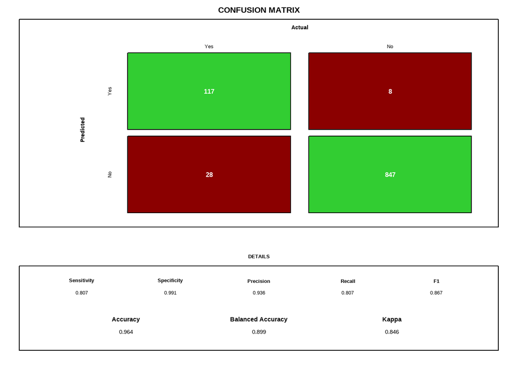

```r
draw_confusion_matrix(subset_test, cm_w ,"churn")
```

The confusion matrix and metrics table offer a thorough assessment of the machine learning model’s performance.

The confusion matrix reveals that the model accurately predicts **117** instances as positive and **847** instances as negative. However, there are **8** instances where the model incorrectly predicts a negative instance as positive, and **28** instances where a positive instance is incorrectly predicted as negative.

The metrics table provides further insights:

- High accuracy: The model achieves an overall accuracy of 96.4% in correctly classifying instances.
- Strong true positive and true negative rates: Sensitivity of 80.7% and Specificity of 99.1% indicate the model accurately identifies both positive and negative instances.
- Excellent precision: Precision of 93.6% reflects a high percentage of correct positive predictions.
- Good recall: Recall of 80.7% approaches Sensitivity, showing the model correctly identifies most positive instances.
- Strong F1 score: The balanced F1 of 86.7% confirms a favorable balance between precision and recall.
- Outperforms random chance: The Kappa statistic of 84.6% signifies the model’s predictions substantially outdo random guessing.

## Calculating the Variable Importance

```r
var_importance <- varImp(weighted_models$randomForest_w)
var_importance
```

```
## rf variable importance
##
##                            Overall
## totaldayminutes            100.000
## totaldaycharge              96.989
## numbercustomerservicecalls  75.280
## totaleveminutes             44.877
## internationalplanyes        43.427
## totalevecharge              41.690
## totalintlcalls              35.739
## totalnightminutes           17.791
## totalnightcharge            17.241
## totalintlcharge             15.823
## totalintlminutes            15.511
## numbervmailmessages          8.269
## voicemailplanyes             0.000
```

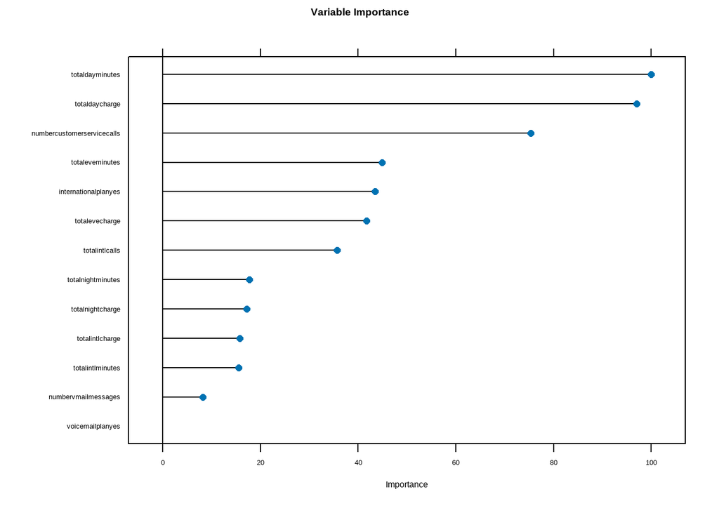

```r
plot(var_importance, main = "Variable Importance")
```

The results from the Random Forest model’s variable importance provide insights into the relative significance of each feature in predicting the target variable.

The `totaldayminutes` variable emerges as the most important, boasting a score of 100. This indicates that the number of minutes spent on calls during the day significantly impacts the model’s predictions.

`totaldaycharge` follows closely with a score of approximately 97, suggesting that the charges incurred for calls made during the day also have a substantial influence on the model’s predictions.

The `numbercustomerservicecalls` variable, scoring approximately 75, is another notable predictor. This indicates that the number of customer service calls made significantly influences the outcome.

Variables such as `totaleveminutes`, `internationalplanyes`, and `totalevecharge` also contribute to the model’s predictions, albeit to a lesser extent compared to the top three variables.

Conversely, variables like `voicemailplanyes` and `numbervmailmessages` bear low importance scores, implying they have minimal impact on the model’s predictions.

# Conclusion and Recommendations

The analysis of the customer dataset provides several key insights and evaluates the performance of various predictive models. The dataset, which contains information about 5,000 customers across 18 variables, identifies `churn` as the target variable. A significant imbalance is observed in the `churn` variable, with a larger number of customers retaining their subscription compared to those who discontinue their service.

To address this imbalance, different models apply various techniques, including weighting mechanisms, up-sampling, down-sampling, and Synthetic Minority Over-sampling Technique (SMOTE). Recursive Feature Elimination (RFE) is used for feature selection, identifying 13 key variables as crucial predictors of customer churn.

The `randomForest_w` model outperforms all others. This model uses a weighting mechanism to handle class imbalance and shows excellent performance on both training and test sets. It achieves an F1 score of 86.7% and a balanced accuracy of 89.9%, considering the imbalanced dataset. The model’s robust performance in correctly classifying instances is reflected in a Kappa statistic of 84.6%.

Based on these insights, the following recommendations are proposed:

1. **Focus on Daytime Usage**: As `totaldayminutes` and `totaldaycharge` are the most influential variables, focusing on customers’ daytime usage patterns could be beneficial. Offering tailored packages or discounts during the day might help retain customers.
2. **Improve Customer Service**: The `numbercustomerservicecalls` variable is a significant predictor of churn. This suggests that customers who make more service calls are more likely to churn. Therefore, improving customer service quality and resolving issues promptly could reduce the number of service calls and potentially decrease churn.
3. **Less Significant Variables**: Variables like `voicemailplanyes` and `numbervmailmessages` have minimal impact on the model’s predictions. While these features shouldn’t be ignored, they might not require as much attention in retention strategies.